# Employee Attrition for Frito Lay

Daanesh Ibrahim

March 13, 2020

#Introduction Frito Lay has asked us to look into their talent management solutions. We were given three data sets which included a wide variety of information from their existing employees (such as Salary, Job Roles, Age, etc.). We do not have the actual reason an employee chose to leave the company (or stay), however we were able to use the data given to create and validate an attrition classification model. Also we built a predictive model for an employee’s monthly income. You can find the prediction results and final presentation of this project in the links below:

#### GitHub Repo: https://github.com/daaneshi/CaseStudy2DDS

#Analysis ####Downloading and Importing the Data

```r
#Importing the raw case study file
EmpData <-read.csv(file.choose(), header = TRUE, sep = ",")
head(EmpData)
```

```
##   ID Age Attrition    BusinessTravel DailyRate             Department
## 1  1  32        No     Travel_Rarely       117                  Sales
## 2  2  40        No     Travel_Rarely      1308 Research & Development
## 3  3  35        No Travel_Frequently       200 Research & Development
## 4  4  32        No     Travel_Rarely       801                  Sales
## 5  5  24        No Travel_Frequently       567 Research & Development
## 6  6  27        No Travel_Frequently       294 Research & Development
##   DistanceFromHome Education   EducationField EmployeeCount EmployeeNumber
## 1               13         4    Life Sciences             1            859
## 2               14         3          Medical             1           1128
## 3               18         2    Life Sciences             1           1412
## 4                1         4        Marketing             1           2016
## 5                2         1 Technical Degree             1           1646
## 6               10         2    Life Sciences             1            733
##   EnvironmentSatisfaction Gender HourlyRate JobInvolvement JobLevel
```

[output cut: 48 more lines]

```r
str(EmpData)
```

```
## 'data.frame':    870 obs. of  36 variables:
##  $ ID                      : int  1 2 3 4 5 6 7 8 9 10 ...
##  $ Age                     : int  32 40 35 32 24 27 41 37 34 34 ...
##  $ Attrition               : Factor w/ 2 levels "No","Yes": 1 1 1 1 1 1 1 1 1 1 ...
##  $ BusinessTravel          : Factor w/ 3 levels "Non-Travel","Travel_Frequently",..: 3 3 2 3 2 2 3 3 3 2 ...
##  $ DailyRate               : int  117 1308 200 801 567 294 1283 309 1333 653 ...
##  $ Department              : Factor w/ 3 levels "Human Resources",..: 3 2 2 3 2 2 2 3 3 2 ...
##  $ DistanceFromHome        : int  13 14 18 1 2 10 5 10 10 10 ...
##  $ Education               : int  4 3 2 4 1 2 5 4 4 4 ...
##  $ EducationField          : Factor w/ 6 levels "Human Resources",..: 2 4 2 3 6 2 4 2 2 6 ...
##  $ EmployeeCount           : int  1 1 1 1 1 1 1 1 1 1 ...
##  $ EmployeeNumber          : int  859 1128 1412 2016 1646 733 1448 1105 1055 1597 ...
##  $ EnvironmentSatisfaction : int  2 3 3 3 1 4 2 4 3 4 ...
##  $ Gender                  : Factor w/ 2 levels "Female","Male": 2 2 2 1 1 2 2 1 1 2 ...
##  $ HourlyRate              : int  73 44 60 48 32 32 90 88 87 92 ...
```

[output cut: 22 more lines]

```r
#Importing Attrition File
Attr_Data <-read.csv(file.choose(), header = TRUE, sep = ",")
str(Attr_Data)
```

```
## 'data.frame':    300 obs. of  35 variables:
##  $ ID                      : int  1171 1172 1173 1174 1175 1176 1177 1178 1179 1180 ...
##  $ Age                     : int  35 33 26 55 29 51 52 39 31 31 ...
##  $ BusinessTravel          : Factor w/ 3 levels "Non-Travel","Travel_Frequently",..: 3 3 3 3 3 2 1 3 3 2 ...
##  $ DailyRate               : int  750 147 1330 1311 1246 1456 585 1387 1062 534 ...
##  $ Department              : Factor w/ 3 levels "Human Resources",..: 2 1 2 2 3 2 3 2 2 2 ...
##  $ DistanceFromHome        : int  28 2 21 2 19 1 29 10 24 20 ...
##  $ Education               : int  3 3 3 3 3 4 4 5 3 3 ...
##  $ EducationField          : Factor w/ 6 levels "Human Resources",..: 2 1 4 2 2 4 2 4 4 2 ...
##  $ EmployeeCount           : int  1 1 1 1 1 1 1 1 1 1 ...
##  $ EmployeeNumber          : int  1596 1207 1107 505 1497 145 2019 1618 1252 587 ...
##  $ EnvironmentSatisfaction : int  2 2 1 3 3 1 1 2 3 1 ...
##  $ Gender                  : Factor w/ 2 levels "Female","Male": 2 2 2 1 2 1 2 2 1 2 ...
##  $ HourlyRate              : int  46 99 37 97 77 30 40 76 96 66 ...
##  $ JobInvolvement          : int  4 3 3 3 2 2 3 3 2 3 ...
```

[output cut: 21 more lines]

```r
#Importing Salary File
Income_Data <-read.csv(file.choose(), header = TRUE, sep = ",")
str(Income_Data)
```

```
## 'data.frame':    300 obs. of  35 variables:
##  $ ID                      : int  871 872 873 874 875 876 877 878 879 880 ...
##  $ Age                     : int  43 33 55 36 27 39 33 21 30 51 ...
##  $ Attrition               : Factor w/ 2 levels "No","Yes": 1 1 2 1 1 2 1 2 1 1 ...
##  $ BusinessTravel          : Factor w/ 3 levels "Non-Travel","Travel_Frequently",..: 2 3 3 1 3 3 1 2 2 3 ...
##  $ DailyRate               : int  1422 461 267 1351 1302 895 750 251 1312 1405 ...
##  $ Department              : Factor w/ 3 levels "Human Resources",..: 3 2 3 2 2 3 3 2 2 2 ...
##  $ DistanceFromHome        : int  2 13 13 9 19 5 22 10 23 11 ...
##  $ Education               : int  4 1 4 4 3 3 2 2 3 2 ...
##  $ EducationField          : Factor w/ 6 levels "Human Resources",..: 2 2 3 2 5 6 3 2 2 6 ...
##  $ EmployeeCount           : int  1 1 1 1 1 1 1 1 1 1 ...
##  $ EmployeeNumber          : int  1849 995 1372 1949 1619 42 160 1279 159 1367 ...
##  $ EnvironmentSatisfaction : int  1 2 1 1 4 4 3 1 1 4 ...
##  $ Gender                  : Factor w/ 2 levels "Female","Male": 2 1 2 2 2 2 2 1 2 1 ...
##  $ HourlyRate              : int  92 53 85 66 67 56 95 45 96 82 ...
```

[output cut: 21 more lines]

```r
head(Income_Data)
```

```
##    ID Age Attrition    BusinessTravel DailyRate             Department
## 1 871  43        No Travel_Frequently      1422                  Sales
## 2 872  33        No     Travel_Rarely       461 Research & Development
## 3 873  55       Yes     Travel_Rarely       267                  Sales
## 4 874  36        No        Non-Travel      1351 Research & Development
## 5 875  27        No     Travel_Rarely      1302 Research & Development
## 6 876  39       Yes     Travel_Rarely       895                  Sales
##   DistanceFromHome Education   EducationField EmployeeCount EmployeeNumber
## 1                2         4    Life Sciences             1           1849
## 2               13         1    Life Sciences             1            995
## 3               13         4        Marketing             1           1372
## 4                9         4    Life Sciences             1           1949
## 5               19         3            Other             1           1619
## 6                5         3 Technical Degree             1             42
##   EnvironmentSatisfaction Gender HourlyRate JobInvolvement JobLevel
```

[output cut: 41 more lines]

##Initial Exploratory Plots

```r
library(tidyverse)
```

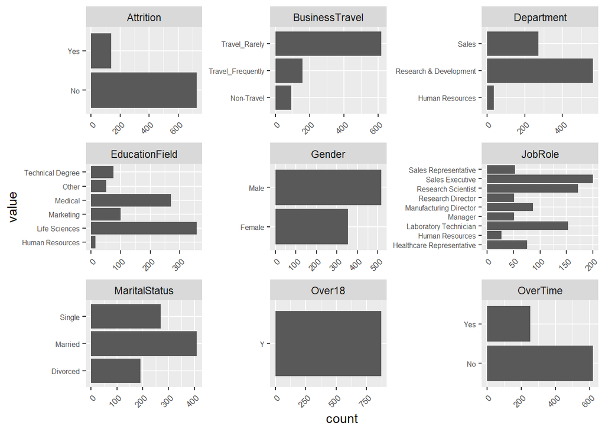

```r
library(dplyr)
library(ggplot2)
library(purrr)
library(corrplot)
library(caret)
library(e1071)
library(leaps)
library(ggrepel)
#Bar graphs for only the factor variables
EmpData %>% keep(is.factor) %>%
gather() %>%
ggplot(aes(value)) +
facet_wrap(~ key, scales="free") +
coord_flip() +
geom_bar() +
theme(axis.text.x=element_text(size=7, angle=45, vjust=1, hjust=1),
      axis.text.y=element_text(size=6))
```

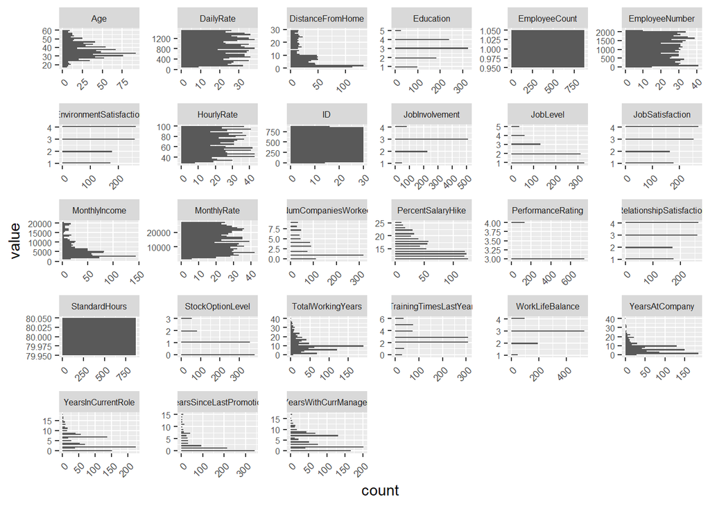

```r
#Histogram of only the integer variables
EmpData %>% keep(is.integer) %>%
gather() %>%
ggplot(aes(value)) +
facet_wrap(~ key, scales="free") +
coord_flip() +
geom_histogram() +
theme(axis.text.x=element_text(size=7, angle=45, vjust=1, hjust=1),
      axis.text.y=element_text(size=6),
      strip.text = element_text(size=6))
```

##Cleaning Datasets

####Right off the bat we can eliminate 3 columns due to them having the same value for every row: - Over18 (‘Y’ in every row) - EmployeeCount (‘1’ in every row) - StandardHours (‘80’ in every row)

####Variables initially classified as integars should actually be categorical and therefore will be converted to factors

```r
##Removing Over18, EmployeeCount, and StandardHours variables
EmpData2 <- EmpData[,-c(10, 23, 28)]
str(EmpData2)
```

```
## 'data.frame':    870 obs. of  33 variables:
##  $ ID                      : int  1 2 3 4 5 6 7 8 9 10 ...
##  $ Age                     : int  32 40 35 32 24 27 41 37 34 34 ...
##  $ Attrition               : Factor w/ 2 levels "No","Yes": 1 1 1 1 1 1 1 1 1 1 ...
##  $ BusinessTravel          : Factor w/ 3 levels "Non-Travel","Travel_Frequently",..: 3 3 2 3 2 2 3 3 3 2 ...
##  $ DailyRate               : int  117 1308 200 801 567 294 1283 309 1333 653 ...
##  $ Department              : Factor w/ 3 levels "Human Resources",..: 3 2 2 3 2 2 2 3 3 2 ...
##  $ DistanceFromHome        : int  13 14 18 1 2 10 5 10 10 10 ...
##  $ Education               : int  4 3 2 4 1 2 5 4 4 4 ...
##  $ EducationField          : Factor w/ 6 levels "Human Resources",..: 2 4 2 3 6 2 4 2 2 6 ...
##  $ EmployeeNumber          : int  859 1128 1412 2016 1646 733 1448 1105 1055 1597 ...
##  $ EnvironmentSatisfaction : int  2 3 3 3 1 4 2 4 3 4 ...
##  $ Gender                  : Factor w/ 2 levels "Female","Male": 2 2 2 1 1 2 2 1 1 2 ...
##  $ HourlyRate              : int  73 44 60 48 32 32 90 88 87 92 ...
##  $ JobInvolvement          : int  3 2 3 3 3 3 4 2 3 2 ...
```

[output cut: 19 more lines]

```r
#Changing Rating Variables seen as Integers to Factors
EmpData2$Education <- as.factor(EmpData2$Education)
EmpData2$EnvironmentSatisfaction <- as.factor(EmpData2$EnvironmentSatisfaction)
EmpData2$JobInvolvement <- as.factor(EmpData2$JobInvolvement)
EmpData2$JobLevel <- as.factor(EmpData2$JobLevel)
EmpData2$JobSatisfaction <- as.factor(EmpData2$JobSatisfaction)
EmpData2$PerformanceRating <- as.factor(EmpData2$PerformanceRating)
EmpData2$RelationshipSatisfaction <- as.factor(EmpData2$RelationshipSatisfaction)
EmpData2$StockOptionLevel <- as.factor(EmpData2$StockOptionLevel)
EmpData2$TrainingTimesLastYear <- as.factor(EmpData2$TrainingTimesLastYear)
EmpData2$WorkLifeBalance <- as.factor(EmpData2$WorkLifeBalance)
#NA Check
colSums(is.na(EmpData2))
```

```
##                       ID                      Age                Attrition
##                        0                        0                        0
##           BusinessTravel                DailyRate               Department
##                        0                        0                        0
##         DistanceFromHome                Education           EducationField
##                        0                        0                        0
##           EmployeeNumber  EnvironmentSatisfaction                   Gender
##                        0                        0                        0
##               HourlyRate           JobInvolvement                 JobLevel
##                        0                        0                        0
##                  JobRole          JobSatisfaction            MaritalStatus
##                        0                        0                        0
##            MonthlyIncome              MonthlyRate       NumCompaniesWorked
##                        0                        0                        0
##                 OverTime        PercentSalaryHike        PerformanceRating
##                        0                        0                        0
## RelationshipSatisfaction         StockOptionLevel        TotalWorkingYears
##                        0                        0                        0
##    TrainingTimesLastYear          WorkLifeBalance           YearsAtCompany
##                        0                        0                        0
##       YearsInCurrentRole  YearsSinceLastPromotion     YearsWithCurrManager
##                        0                        0                        0
```

```r
#cleaning Attriction Validation File
##Removing Over18, EmployeeCount, and StandardHours variables
Attr_Data <- Attr_Data[,-c(9, 22, 27)]
str(Attr_Data)
```

```
## 'data.frame':    300 obs. of  32 variables:
##  $ ID                      : int  1171 1172 1173 1174 1175 1176 1177 1178 1179 1180 ...
##  $ Age                     : int  35 33 26 55 29 51 52 39 31 31 ...
##  $ BusinessTravel          : Factor w/ 3 levels "Non-Travel","Travel_Frequently",..: 3 3 3 3 3 2 1 3 3 2 ...
##  $ DailyRate               : int  750 147 1330 1311 1246 1456 585 1387 1062 534 ...
##  $ Department              : Factor w/ 3 levels "Human Resources",..: 2 1 2 2 3 2 3 2 2 2 ...
##  $ DistanceFromHome        : int  28 2 21 2 19 1 29 10 24 20 ...
##  $ Education               : int  3 3 3 3 3 4 4 5 3 3 ...
##  $ EducationField          : Factor w/ 6 levels "Human Resources",..: 2 1 4 2 2 4 2 4 4 2 ...
##  $ EmployeeNumber          : int  1596 1207 1107 505 1497 145 2019 1618 1252 587 ...
##  $ EnvironmentSatisfaction : int  2 2 1 3 3 1 1 2 3 1 ...
##  $ Gender                  : Factor w/ 2 levels "Female","Male": 2 2 2 1 2 1 2 2 1 2 ...
##  $ HourlyRate              : int  46 99 37 97 77 30 40 76 96 66 ...
##  $ JobInvolvement          : int  4 3 3 3 2 2 3 3 2 3 ...
##  $ JobLevel                : int  2 1 1 4 2 3 1 2 2 3 ...
```

[output cut: 18 more lines]

```r
#Casting Rating Variables as Factors
Attr_Data$Education <- as.factor(Attr_Data$Education)
Attr_Data$EnvironmentSatisfaction <- as.factor(Attr_Data$EnvironmentSatisfaction)
Attr_Data$JobInvolvement <- as.factor(Attr_Data$JobInvolvement)
Attr_Data$JobLevel <- as.factor(Attr_Data$JobLevel)
Attr_Data$JobSatisfaction <- as.factor(Attr_Data$JobSatisfaction)
Attr_Data$PerformanceRating <- as.factor(Attr_Data$PerformanceRating)
Attr_Data$RelationshipSatisfaction <- as.factor(Attr_Data$RelationshipSatisfaction)
Attr_Data$StockOptionLevel <- as.factor(Attr_Data$StockOptionLevel)
Attr_Data$TrainingTimesLastYear <- as.factor(Attr_Data$TrainingTimesLastYear)
Attr_Data$WorkLifeBalance <- as.factor(Attr_Data$WorkLifeBalance)
#cleaning Income Prediction File
##Removing Over18, EmployeeCount, and StandardHours variables
Income_Data <- Income_Data[,-c(10, 22, 27)]
str(Income_Data)
```

```
## 'data.frame':    300 obs. of  32 variables:
##  $ ID                      : int  871 872 873 874 875 876 877 878 879 880 ...
##  $ Age                     : int  43 33 55 36 27 39 33 21 30 51 ...
##  $ Attrition               : Factor w/ 2 levels "No","Yes": 1 1 2 1 1 2 1 2 1 1 ...
##  $ BusinessTravel          : Factor w/ 3 levels "Non-Travel","Travel_Frequently",..: 2 3 3 1 3 3 1 2 2 3 ...
##  $ DailyRate               : int  1422 461 267 1351 1302 895 750 251 1312 1405 ...
##  $ Department              : Factor w/ 3 levels "Human Resources",..: 3 2 3 2 2 3 3 2 2 2 ...
##  $ DistanceFromHome        : int  2 13 13 9 19 5 22 10 23 11 ...
##  $ Education               : int  4 1 4 4 3 3 2 2 3 2 ...
##  $ EducationField          : Factor w/ 6 levels "Human Resources",..: 2 2 3 2 5 6 3 2 2 6 ...
##  $ EmployeeNumber          : int  1849 995 1372 1949 1619 42 160 1279 159 1367 ...
##  $ EnvironmentSatisfaction : int  1 2 1 1 4 4 3 1 1 4 ...
##  $ Gender                  : Factor w/ 2 levels "Female","Male": 2 1 2 2 2 2 2 1 2 1 ...
##  $ HourlyRate              : int  92 53 85 66 67 56 95 45 96 82 ...
##  $ JobInvolvement          : int  3 3 4 4 2 3 3 2 1 2 ...
```

[output cut: 18 more lines]

```r
#Casting Rating Variables as Factors
Income_Data$Education <- as.factor(Income_Data$Education)
Income_Data$EnvironmentSatisfaction <- as.factor(Income_Data$EnvironmentSatisfaction)
Income_Data$JobInvolvement <- as.factor(Income_Data$JobInvolvement)
Income_Data$JobLevel <- as.factor(Income_Data$JobLevel)
Income_Data$JobSatisfaction <- as.factor(Income_Data$JobSatisfaction)
Income_Data$PerformanceRating <- as.factor(Income_Data$PerformanceRating)
Income_Data$RelationshipSatisfaction <- as.factor(Income_Data$RelationshipSatisfaction)
Income_Data$StockOptionLevel <- as.factor(Income_Data$StockOptionLevel)
Income_Data$TrainingTimesLastYear <- as.factor(Income_Data$TrainingTimesLastYear)
Income_Data$WorkLifeBalance <- as.factor(Income_Data$WorkLifeBalance)
```

##Correlation Plots

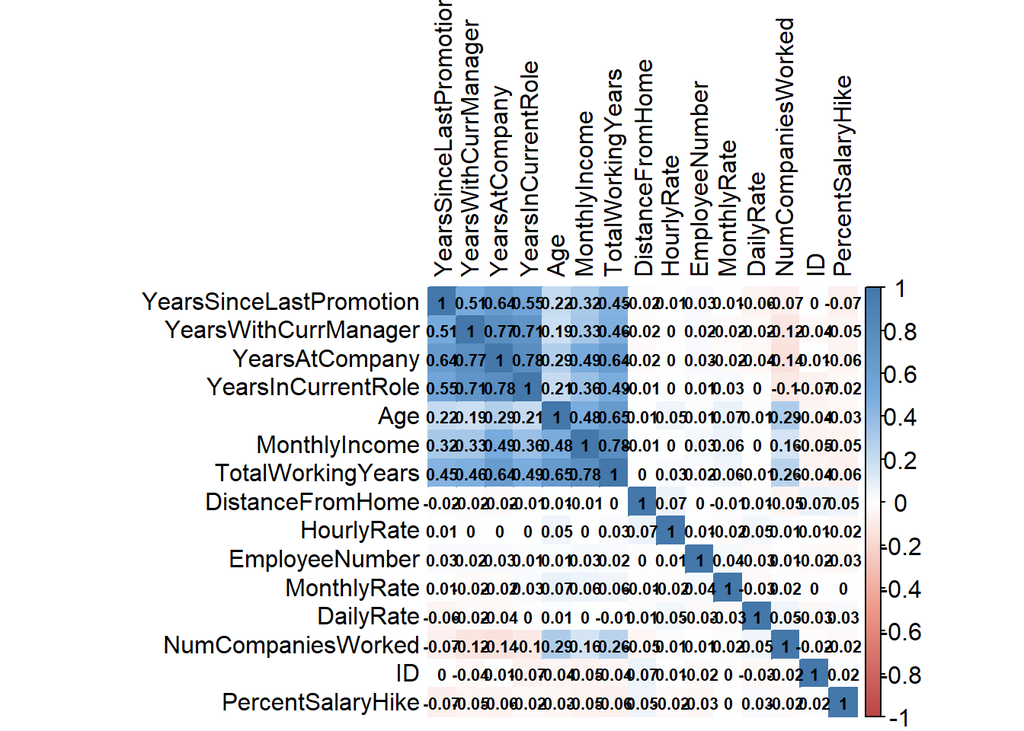

```r
#Testing to see if the Integer Variables have Correlation with each other
EmpCor <- cor(EmpData2 %>% keep(is.integer))
col <- colorRampPalette(c("#BB4444", "#EE9988", "#FFFFFF", "#77AADD", "#4477AA"))
cex.before <- par("cex")
par(cex = 0.7)
corrplot(EmpCor, method="color", col=col(200),
         type="full", order="hclust",
         addCoef.col = "black", # Add coefficient of correlation
         tl.cex = 1/par("cex"),
         cl.cex = 1/par("cex"),
         tl.col="black", tl.srt=90, #Text label color and rotation
         # hide correlation coefficient on the principal diagonal
         diag=TRUE)
```

```r
         par(cex = cex.before)
```

##Attrition Frequencies

```r
#Creating Attrition Proportion Tables
TotalAT <- table(EmpData2$Attrition)
BusTravAT <- table(EmpData2$BusinessTravel,EmpData2$Attrition)
DeptAT <- table(EmpData2$Department,EmpData2$Attrition)
EduFieldAT <- table(EmpData2$EducationField,EmpData2$Attrition)
GenderAT <- table(EmpData2$Gender,EmpData2$Attrition)
RoleAT <- table(EmpData2$JobRole,EmpData2$Attrition)
MaritalAT <- table(EmpData2$MaritalStatus,EmpData2$Attrition)
OverTimeAT <- table(EmpData2$OverTime,EmpData2$Attrition)
EducationAT <- table(EmpData2$Education,EmpData2$Attrition)
EnvirSatAT <- table(EmpData2$EnvironmentSatisfaction,EmpData2$Attrition)
JobInvAT <- table(EmpData2$JobInvolvement,EmpData2$Attrition)
JobLevAT <- table(EmpData2$JobLevel,EmpData2$Attrition)
JobSatAT <- table(EmpData2$JobSatisfaction,EmpData2$Attrition)
PerRatAT <- table(EmpData2$PerformanceRating,EmpData2$Attrition)
RelSatAT <- table(EmpData2$RelationshipSatisfaction,EmpData2$Attrition)
StockAT <- table(EmpData2$StockOptionLevel,EmpData2$Attrition)
TrainTimeAT <- table(EmpData2$TrainingTimesLastYear,EmpData2$Attrition)
WorkLifeAT <- table(EmpData2$WorkLifeBalance,EmpData2$Attrition)
#Getting Percentages
Total_Table <- prop.table(TotalAT)
BusTrav_Table <- data.frame(prop.table(BusTravAT, 1))
Dept_Table <- data.frame(prop.table(DeptAT, 1) )
EduFieldAT_Table <- data.frame(prop.table(EduFieldAT, 1) )
Gender_Table <- data.frame(prop.table(GenderAT, 1))
Role_Table <- data.frame(prop.table(RoleAT, 1) )
Marital_Table <- data.frame(prop.table(MaritalAT, 1))
OverTime_Table <- data.frame(prop.table(OverTimeAT, 1))
Education_Table <- data.frame(prop.table(EducationAT, 1))
EnvirSat_Table <- data.frame(prop.table(EnvirSatAT, 1))
JobInv_Table <- data.frame(prop.table(JobInvAT, 1))
JobLev_Table <- data.frame(prop.table(JobLevAT, 1))
JobSat_Table <- data.frame(prop.table(JobSatAT, 1))
PerRat_Table <- data.frame(prop.table(PerRatAT, 1))
RelSat_Table <- data.frame(prop.table(RelSatAT, 1))
Stock_Table <- data.frame(prop.table(StockAT, 1))
TrainTime_Table <- data.frame(prop.table(TrainTimeAT, 1))
WorkLife_Table <- data.frame(prop.table(WorkLifeAT, 1))
#Testing significance of difference in attrition between levels of each variable
prop.test(BusTravAT, correct=FALSE) #sig, p-value = 0.04993
```

```
##
##  3-sample test for equality of proportions without continuity
##  correction
##
## data:  BusTravAT
## X-squared = 5.9945, df = 2, p-value = 0.04993
## alternative hypothesis: two.sided
## sample estimates:
##    prop 1    prop 2    prop 3
## 0.8829787 0.7784810 0.8478964
```

```r
prop.test(DeptAT, correct=FALSE) #sig, p-value = 0.009424
```

```
##
##  3-sample test for equality of proportions without continuity
##  correction
##
## data:  DeptAT
## X-squared = 9.329, df = 2, p-value = 0.009424
## alternative hypothesis: two.sided
## sample estimates:
##    prop 1    prop 2    prop 3
## 0.8285714 0.8665480 0.7838828
```

```r
prop.test(EduFieldAT, correct=FALSE) ##insig, p-value = 0.2682
```

```
##
##  6-sample test for equality of proportions without continuity
##  correction
##
## data:  EduFieldAT
## X-squared = 6.4114, df = 5, p-value = 0.2682
## alternative hypothesis: two.sided
## sample estimates:
##    prop 1    prop 2    prop 3    prop 4    prop 5    prop 6
## 0.7333333 0.8519553 0.8000000 0.8629630 0.8269231 0.7733333
```

```r
prop.test(GenderAT, correct=FALSE) #insig, p-value = 0.4564
```

```
##
##  2-sample test for equality of proportions without continuity
##  correction
##
## data:  GenderAT
## X-squared = 0.55469, df = 1, p-value = 0.4564
## alternative hypothesis: two.sided
## 95 percent confidence interval:
##  -0.03035720  0.06813147
## sample estimates:
##    prop 1    prop 2
## 0.8502825 0.8313953
```

```r
prop.test(RoleAT, correct=FALSE) ##sig, p-value = 3.647e-10
```

```
##
##  9-sample test for equality of proportions without continuity
##  correction
##
## data:  RoleAT
## X-squared = 60.543, df = 8, p-value = 3.647e-10
## alternative hypothesis: two.sided
## sample estimates:
##    prop 1    prop 2    prop 3    prop 4    prop 5    prop 6    prop 7
## 0.8947368 0.7777778 0.8039216 0.9215686 0.9770115 0.9803922 0.8139535
##    prop 8    prop 9
## 0.8350000 0.5471698
```

```r
prop.test(MaritalAT, correct=FALSE) #sig, p-value = 3.379e-08
```

```
##
##  3-sample test for equality of proportions without continuity
##  correction
##
## data:  MaritalAT
## X-squared = 34.406, df = 2, p-value = 3.379e-08
## alternative hypothesis: two.sided
## sample estimates:
##    prop 1    prop 2    prop 3
## 0.9371728 0.8585366 0.7397770
```

```r
prop.test(OverTimeAT, correct=FALSE) #sig, p-value = 1.024e-15
```

```
##
##  2-sample test for equality of proportions without continuity
##  correction
##
## data:  OverTimeAT
## X-squared = 64.383, df = 1, p-value = 1.024e-15
## alternative hypothesis: two.sided
## 95 percent confidence interval:
##  0.1583412 0.2824046
## sample estimates:
##    prop 1    prop 2
## 0.9029126 0.6825397
```

```r
prop.test(EducationAT, correct=FALSE) ##insig, p-value = 0.6243
```

```
##
##  5-sample test for equality of proportions without continuity
##  correction
##
## data:  EducationAT
## X-squared = 2.6143, df = 4, p-value = 0.6243
## alternative hypothesis: two.sided
## sample estimates:
##    prop 1    prop 2    prop 3    prop 4    prop 5
## 0.8163265 0.8241758 0.8302469 0.8666667 0.8846154
```

```r
prop.test(EnvirSatAT, correct=FALSE) #sig, p-value = 0.01054
```

```
##
##  4-sample test for equality of proportions without continuity
##  correction
##
## data:  EnvirSatAT
## X-squared = 11.231, df = 3, p-value = 0.01054
## alternative hypothesis: two.sided
## sample estimates:
##    prop 1    prop 2    prop 3    prop 4
## 0.7558140 0.8651685 0.8643411 0.8511450
```

```r
prop.test(JobInvAT, correct=FALSE) #sig, p-value = 5.211e-09
```

```
##
##  4-sample test for equality of proportions without continuity
##  correction
##
## data:  JobInvAT
## X-squared = 41.465, df = 3, p-value = 5.211e-09
## alternative hypothesis: two.sided
## sample estimates:
##    prop 1    prop 2    prop 3    prop 4
## 0.5319149 0.8070175 0.8696498 0.9135802
```

```r
prop.test(JobLevAT, correct=FALSE) #sig, p-value = 2.085e-08
```

```
##
##  5-sample test for equality of proportions without continuity
##  correction
##
## data:  JobLevAT
## X-squared = 41.533, df = 4, p-value = 2.085e-08
## alternative hypothesis: two.sided
## sample estimates:
##    prop 1    prop 2    prop 3    prop 4    prop 5
## 0.7386018 0.9038462 0.8712121 0.9500000 0.8918919
```

```r
prop.test(JobSatAT, correct=FALSE) #sig, p-value = 0.01115
```

```
##
##  4-sample test for equality of proportions without continuity
##  correction
##
## data:  JobSatAT
## X-squared = 11.109, df = 3, p-value = 0.01115
## alternative hypothesis: two.sided
## sample estimates:
##    prop 1    prop 2    prop 3    prop 4
## 0.7877095 0.8132530 0.8307087 0.8966790
```

```r
prop.test(PerRatAT, correct=FALSE) #insig, p-value = 0.6511
```

```
##
##  2-sample test for equality of proportions without continuity
##  correction
##
## data:  PerRatAT
## X-squared = 0.20456, df = 1, p-value = 0.6511
## alternative hypothesis: two.sided
## 95 percent confidence interval:
##  -0.05416290  0.08557457
## sample estimates:
##    prop 1    prop 2
## 0.8414634 0.8257576
```

```r
prop.test(RelSatAT, correct=FALSE) #insig, p-value = 0.3727
```

```
##
##  4-sample test for equality of proportions without continuity
##  correction
##
## data:  RelSatAT
## X-squared = 3.1253, df = 3, p-value = 0.3727
## alternative hypothesis: two.sided
## sample estimates:
##    prop 1    prop 2    prop 3    prop 4
## 0.7988506 0.8421053 0.8620690 0.8409091
```

```r
prop.test(StockAT, correct=FALSE) #sig, p-value = 3.724e-12
```

```
##
##  4-sample test for equality of proportions without continuity
##  correction
##
## data:  StockAT
## X-squared = 56.245, df = 3, p-value = 3.724e-12
## alternative hypothesis: two.sided
## sample estimates:
##    prop 1    prop 2    prop 3    prop 4
## 0.7414248 0.9239437 0.9629630 0.7818182
```

```r
prop.test(TrainTimeAT, correct=FALSE) ##insig, p-value = 0.1192
```

```
##
##  7-sample test for equality of proportions without continuity
##  correction
##
## data:  TrainTimeAT
## X-squared = 10.132, df = 6, p-value = 0.1192
## alternative hypothesis: two.sided
## sample estimates:
##    prop 1    prop 2    prop 3    prop 4    prop 5    prop 6    prop 7
## 0.7333333 0.8717949 0.8155340 0.8603896 0.7808219 0.9066667 0.8888889
```

```r
prop.test(WorkLifeAT, correct=FALSE) #sig, p-value = 0.002495
```

```
##
##  4-sample test for equality of proportions without continuity
##  correction
##
## data:  WorkLifeAT
## X-squared = 14.325, df = 3, p-value = 0.002495
## alternative hypothesis: two.sided
## sample estimates:
##    prop 1    prop 2    prop 3    prop 4
## 0.6458333 0.8437500 0.8496241 0.8673469
```

```r
prop.test(table(EmpData2$Age, EmpData2$Attrition), correct=FALSE) ##sig, p-value = 0.0004559
```

```
##
##  43-sample test for equality of proportions without continuity
##  correction
##
## data:  table(EmpData2$Age, EmpData2$Attrition)
## X-squared = 79.178, df = 42, p-value = 0.0004559
## alternative hypothesis: two.sided
## sample estimates:
##    prop 1    prop 2    prop 3    prop 4    prop 5    prop 6    prop 7
## 0.3333333 0.4285714 0.2500000 0.6666667 0.6250000 1.0000000 0.7647059
##    prop 8    prop 9   prop 10   prop 11   prop 12   prop 13   prop 14
## 0.7647059 0.8000000 0.9090909 0.6666667 0.7073171 0.8648649 0.7435897
##   prop 15   prop 16   prop 17   prop 18   prop 19   prop 20   prop 21
## 0.8157895 0.8000000 0.8947368 0.8541667 0.8809524 0.9032258 0.9722222
##   prop 22   prop 23   prop 24   prop 25   prop 26   prop 27   prop 28
## 0.8333333 0.8965517 0.8400000 0.9655172 0.9000000 0.8888889 0.9230769
##   prop 29   prop 30   prop 31   prop 32   prop 33   prop 34   prop 35
## 0.9090909 0.8947368 0.8461538 0.9285714 0.8571429 0.9090909 0.7000000
##   prop 36   prop 37   prop 38   prop 39   prop 40   prop 41   prop 42
## 0.8571429 1.0000000 0.9166667 0.8000000 1.0000000 0.5714286 1.0000000
##   prop 43
## 1.0000000
```

```r
prop.test(table(EmpData2$DailyRate, EmpData2$Attrition), correct=FALSE) ##insig, p-value = 0.3944
```

[output not shown]

[output cut: 133 more lines]

[output not shown]

```r
prop.test(table(EmpData2$DistanceFromHome, EmpData2$Attrition), correct=FALSE) ##sig, p-value = 0.04102
```

```
##
##  29-sample test for equality of proportions without continuity
##  correction
##
## data:  table(EmpData2$DistanceFromHome, EmpData2$Attrition)
## X-squared = 42.255, df = 28, p-value = 0.04102
## alternative hypothesis: two.sided
## sample estimates:
##    prop 1    prop 2    prop 3    prop 4    prop 5    prop 6    prop 7
## 0.8482143 0.8721805 0.8222222 0.8863636 0.8484848 0.8918919 0.8800000
##    prop 8    prop 9   prop 10   prop 11   prop 12   prop 13   prop 14
## 0.9166667 0.7800000 0.8958333 0.8750000 0.8181818 0.6363636 0.7333333
##   prop 15   prop 16   prop 17   prop 18   prop 19   prop 20   prop 21
## 0.8461538 0.8000000 0.8571429 0.8750000 0.8000000 0.7500000 0.8571429
##   prop 22   prop 23   prop 24   prop 25   prop 26   prop 27   prop 28
## 0.5833333 0.7857143 0.5000000 0.8750000 0.9285714 0.8750000 0.9230769
##   prop 29
## 0.7142857
```

```r
prop.test(table(EmpData2$HourlyRate, EmpData2$Attrition), correct=FALSE) ##insig, p-value = 0.1653
```

```
##
##  71-sample test for equality of proportions without continuity
##  correction
##
## data:  table(EmpData2$HourlyRate, EmpData2$Attrition)
## X-squared = 81.419, df = 70, p-value = 0.1653
## alternative hypothesis: two.sided
## sample estimates:
##    prop 1    prop 2    prop 3    prop 4    prop 5    prop 6    prop 7
## 1.0000000 1.0000000 0.9166667 0.8333333 0.5714286 1.0000000 0.6666667
##    prop 8    prop 9   prop 10   prop 11   prop 12   prop 13   prop 14
## 0.8888889 0.6250000 0.8000000 0.8333333 0.9090909 1.0000000 0.9411765
##   prop 15   prop 16   prop 17   prop 18   prop 19   prop 20   prop 21
## 1.0000000 0.8666667 0.7058824 0.9090909 0.9333333 0.8333333 0.6250000
##   prop 22   prop 23   prop 24   prop 25   prop 26   prop 27   prop 28
## 0.8333333 0.8750000 0.8571429 0.7777778 0.8888889 0.9375000 0.8333333
##   prop 29   prop 30   prop 31   prop 32   prop 33   prop 34   prop 35
## 0.7500000 1.0000000 0.9333333 0.8181818 0.8333333 1.0000000 0.7500000
##   prop 36   prop 37   prop 38   prop 39   prop 40   prop 41   prop 42
## 0.8571429 0.5833333 0.8333333 0.8181818 0.7142857 0.5384615 0.8181818
##   prop 43   prop 44   prop 45   prop 46   prop 47   prop 48   prop 49
## 0.7894737 0.7142857 1.0000000 0.9166667 0.9285714 0.8000000 0.9166667
##   prop 50   prop 51   prop 52   prop 53   prop 54   prop 55   prop 56
## 0.7222222 0.9285714 0.9285714 0.8461538 1.0000000 0.7058824 0.6363636
##   prop 57   prop 58   prop 59   prop 60   prop 61   prop 62   prop 63
## 0.8333333 1.0000000 0.8333333 0.7142857 0.9000000 1.0000000 0.8125000
##   prop 64   prop 65   prop 66   prop 67   prop 68   prop 69   prop 70
## 1.0000000 0.7857143 0.8125000 0.7692308 0.7272727 0.9285714 0.7000000
##   prop 71
## 0.7692308
```

```r
prop.test(table(EmpData2$MonthlyRate, EmpData2$Attrition), correct=FALSE) ##insig, p-value = 0.5366
```

[output not shown]

[output cut: 197 more lines]

[output not shown]

```r
prop.test(table(EmpData2$MonthlyIncome, EmpData2$Attrition), correct=FALSE) ##insig, p-value = 0.5485
```

[output not shown]

[output cut: 189 more lines]

[output not shown]

```r
prop.test(table(EmpData2$TotalWorkingYears, EmpData2$Attrition), correct=FALSE) ##sig, p-value = 0.0004072
```

```
##
##  39-sample test for equality of proportions without continuity
##  correction
##
## data:  table(EmpData2$TotalWorkingYears, EmpData2$Attrition)
## X-squared = 74.121, df = 38, p-value = 0.0004072
## alternative hypothesis: two.sided
## sample estimates:
##    prop 1    prop 2    prop 3    prop 4    prop 5    prop 6    prop 7
## 0.2857143 0.5833333 0.6500000 0.7407407 0.8000000 0.7755102 0.8194444
##    prop 8    prop 9   prop 10   prop 11   prop 12   prop 13   prop 14
## 0.8085106 0.8688525 0.9137931 0.8863636 0.8500000 0.9130435 0.8800000
##   prop 15   prop 16   prop 17   prop 18   prop 19   prop 20   prop 21
## 0.8636364 0.8965517 0.8750000 0.8823529 0.8461538 0.9230769 0.9411765
##   prop 22   prop 23   prop 24   prop 25   prop 26   prop 27   prop 28
## 0.9411765 0.9285714 0.8571429 0.8888889 0.8333333 0.8750000 1.0000000
##   prop 29   prop 30   prop 31   prop 32   prop 33   prop 34   prop 35
## 1.0000000 1.0000000 1.0000000 0.8333333 1.0000000 0.5000000 1.0000000
##   prop 36   prop 37   prop 38   prop 39
## 1.0000000 1.0000000 1.0000000 0.0000000
```

```r
prop.test(table(EmpData2$YearsAtCompany, EmpData2$Attrition), correct=FALSE) ##sig, p-value = 7.894e-05
```

```
##
##  32-sample test for equality of proportions without continuity
##  correction
##
## data:  table(EmpData2$YearsAtCompany, EmpData2$Attrition)
## X-squared = 69.893, df = 31, p-value = 7.894e-05
## alternative hypothesis: two.sided
## sample estimates:
##    prop 1    prop 2    prop 3    prop 4    prop 5    prop 6    prop 7
## 0.6071429 0.6728972 0.7532468 0.8823529 0.8148148 0.8857143 0.9318182
##    prop 8    prop 9   prop 10   prop 11   prop 12   prop 13   prop 14
## 0.9047619 0.9000000 0.9038462 0.8571429 0.8823529 1.0000000 0.9000000
##   prop 15   prop 16   prop 17   prop 18   prop 19   prop 20   prop 21
## 0.8571429 0.9090909 0.8333333 0.8000000 0.8750000 1.0000000 1.0000000
##   prop 22   prop 23   prop 24   prop 25   prop 26   prop 27   prop 28
## 1.0000000 0.9166667 0.0000000 0.7500000 1.0000000 1.0000000 1.0000000
##   prop 29   prop 30   prop 31   prop 32
## 1.0000000 0.6666667 1.0000000 0.0000000
```

```r
prop.test(table(EmpData2$YearsInCurrentRole, EmpData2$Attrition), correct=FALSE) ##sig, p-value = 0.0007929
```

```
##
##  19-sample test for equality of proportions without continuity
##  correction
##
## data:  table(EmpData2$YearsInCurrentRole, EmpData2$Attrition)
## X-squared = 43.028, df = 18, p-value = 0.0007929
## alternative hypothesis: two.sided
## sample estimates:
##    prop 1    prop 2    prop 3    prop 4    prop 5    prop 6    prop 7
## 0.6953642 0.8421053 0.8161435 0.8823529 0.8867925 0.9615385 1.0000000
##    prop 8    prop 9   prop 10   prop 11   prop 12   prop 13   prop 14
## 0.8602941 0.9285714 0.9250000 0.8571429 1.0000000 0.8571429 0.8888889
##   prop 15   prop 16   prop 17   prop 18   prop 19
## 0.8571429 0.6666667 1.0000000 1.0000000 1.0000000
```

```r
prop.test(table(EmpData2$YearsSinceLastPromotion, EmpData2$Attrition), correct=FALSE) ##insig, p-value = 0.1294
```

```
##
##  16-sample test for equality of proportions without continuity
##  correction
##
## data:  table(EmpData2$YearsSinceLastPromotion, EmpData2$Attrition)
## X-squared = 21.239, df = 15, p-value = 0.1294
## alternative hypothesis: two.sided
## sample estimates:
##    prop 1    prop 2    prop 3    prop 4    prop 5    prop 6    prop 7
## 0.8157895 0.8785047 0.7978723 0.8125000 0.9375000 0.9666667 0.7826087
##    prop 8    prop 9   prop 10   prop 11   prop 12   prop 13   prop 14
## 0.8048780 1.0000000 0.6666667 0.7500000 0.8571429 1.0000000 1.0000000
##   prop 15   prop 16
## 0.8000000 0.6250000
```

####Using X2 tests (Chi-Squared tests) we compare the attrition rate with thr levels of each variable and test for significances (alpha = 0.05) , ####These variables do not have a significant difference in the Attrition rate: - Education Field - Education (level) - Gender of Employee - Performance Rating - Relationship Satisfaction - Training Time - Daily Rate - Hourly Rate - Monthly Income - Years Since Last Promotion

##Plotting only variables that have significant impact on Attrition Rate (%)

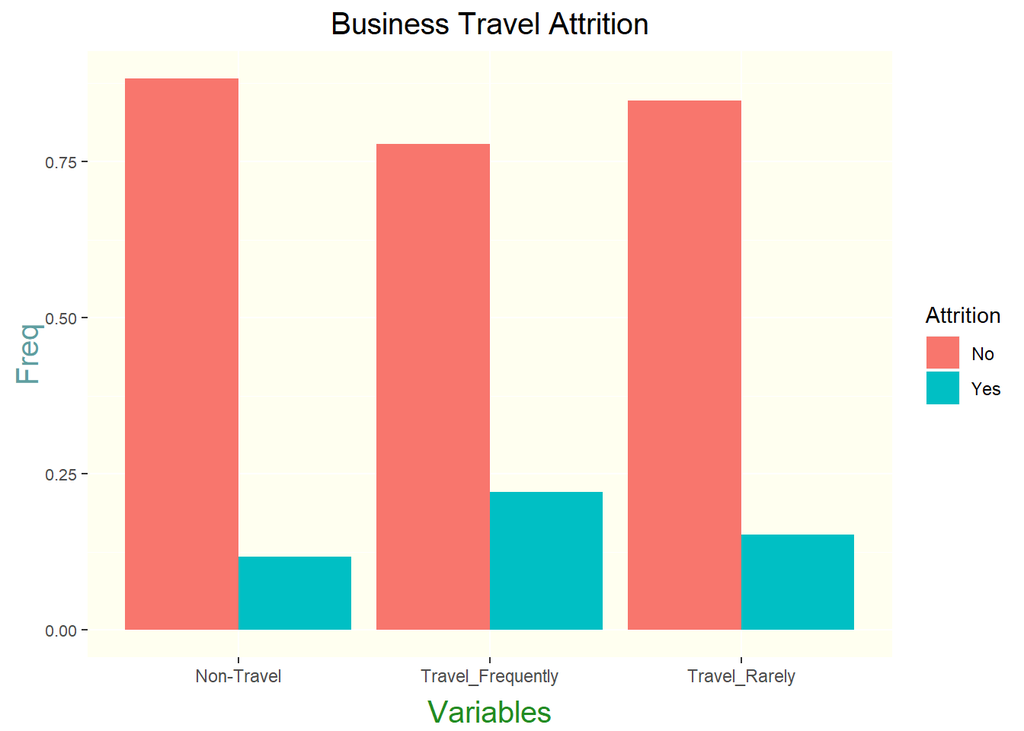

```r
#Plotting Attrition Perctages for Categorical Variables
ggplot(data=BusTrav_Table, aes(x=Var1, y=Freq, fill=Var2)) +
  geom_bar(stat="identity", position=position_dodge()) +
  theme(
        panel.background = element_rect(fill = 'ivory1'),
        plot.title = element_text(hjust = 0.5, size=15),
        axis.text.y = element_text(size=8),
        axis.title.x = element_text(color="forestgreen", vjust=-0.35, size=15),
        axis.title.y = element_text(color="cadetblue" , vjust=0.35, size=15)
        ) +
  labs(fill = "Attrition") +
  ggtitle("Business Travel Attrition")+
  xlab("Variables")
```

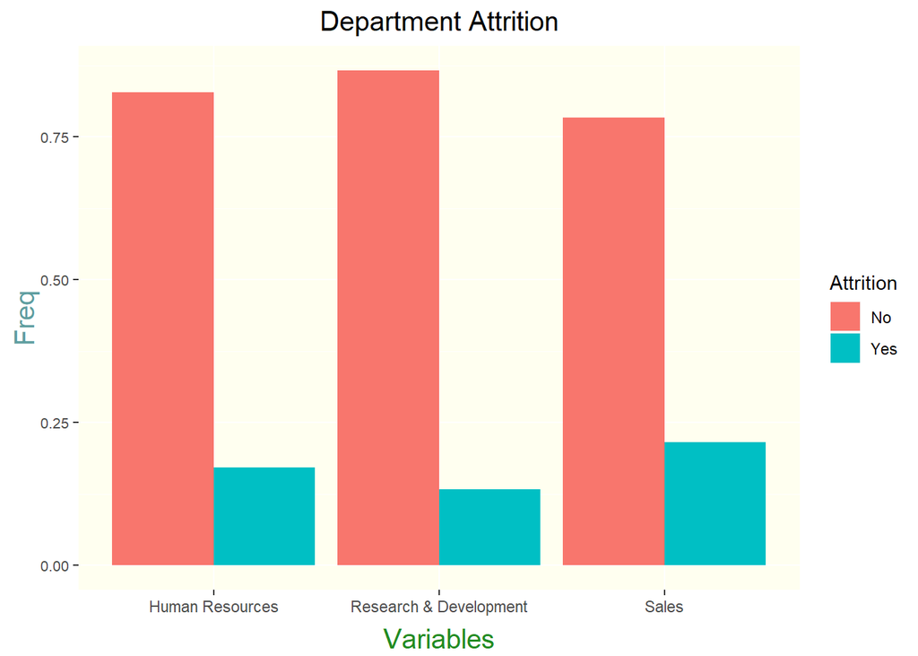

```r
ggplot(data=Dept_Table, aes(x=Var1, y=Freq, fill=Var2)) +
  geom_bar(stat="identity", position=position_dodge()) +
  theme(
        panel.background = element_rect(fill = 'ivory1'),
        plot.title = element_text(hjust = 0.5, size=15),
        axis.text.y = element_text(size=8),
        axis.title.x = element_text(color="forestgreen", vjust=-0.35, size=15),
        axis.title.y = element_text(color="cadetblue" , vjust=0.35, size=15)
        )+
  labs(fill = "Attrition") +
  ggtitle("Department Attrition")+
  xlab("Variables")
```

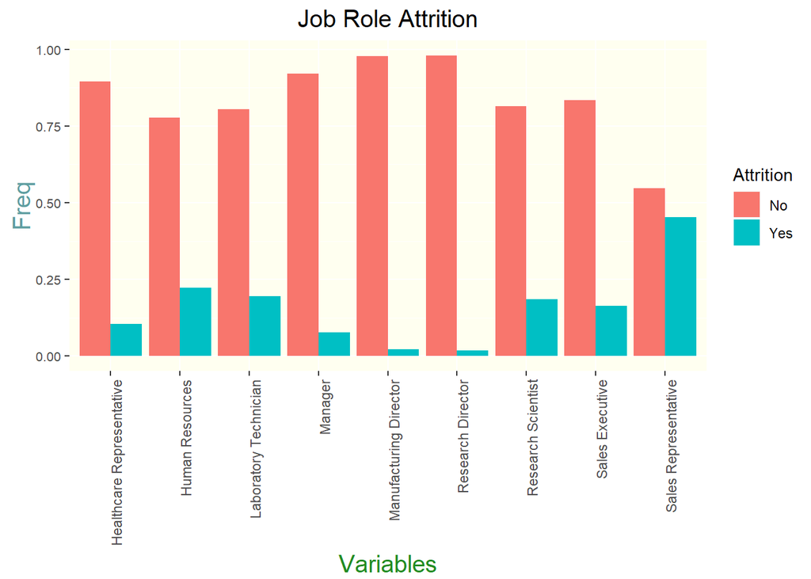

```r
ggplot(data=Role_Table, aes(x=Var1, y=Freq, fill=Var2)) +
  geom_bar(stat="identity", position=position_dodge()) +
theme(
        panel.background = element_rect(fill = 'ivory1'),
        plot.title = element_text(hjust = 0.5, size=15),
        axis.text.y = element_text(size=8),
        axis.title.x = element_text(color="forestgreen", vjust=-0.35, size=15),
        axis.title.y = element_text(color="cadetblue" , vjust=0.35, size=15),
        axis.text.x = element_text(angle = 90, hjust = 1)
        ) +
  labs(fill = "Attrition") +
  ggtitle("Job Role Attrition")+
  xlab("Variables")
```

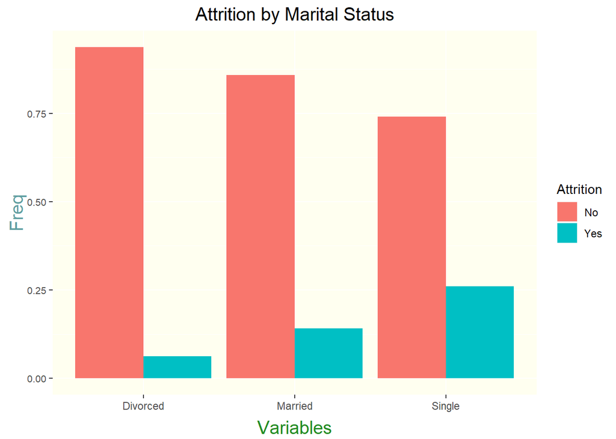

```r
ggplot(data=Marital_Table, aes(x=Var1, y=Freq, fill=Var2)) +
  geom_bar(stat="identity", position=position_dodge()) +
theme(
        panel.background = element_rect(fill = 'ivory1'),
        plot.title = element_text(hjust = 0.5, size=15),
        axis.text.y = element_text(size=8),
        axis.title.x = element_text(color="forestgreen", vjust=-0.35, size=15),
        axis.title.y = element_text(color="cadetblue" , vjust=0.35, size=15)
        )  +
  labs(fill = "Attrition") +
  ggtitle("Attrition by Marital Status")+
  xlab("Variables")
```

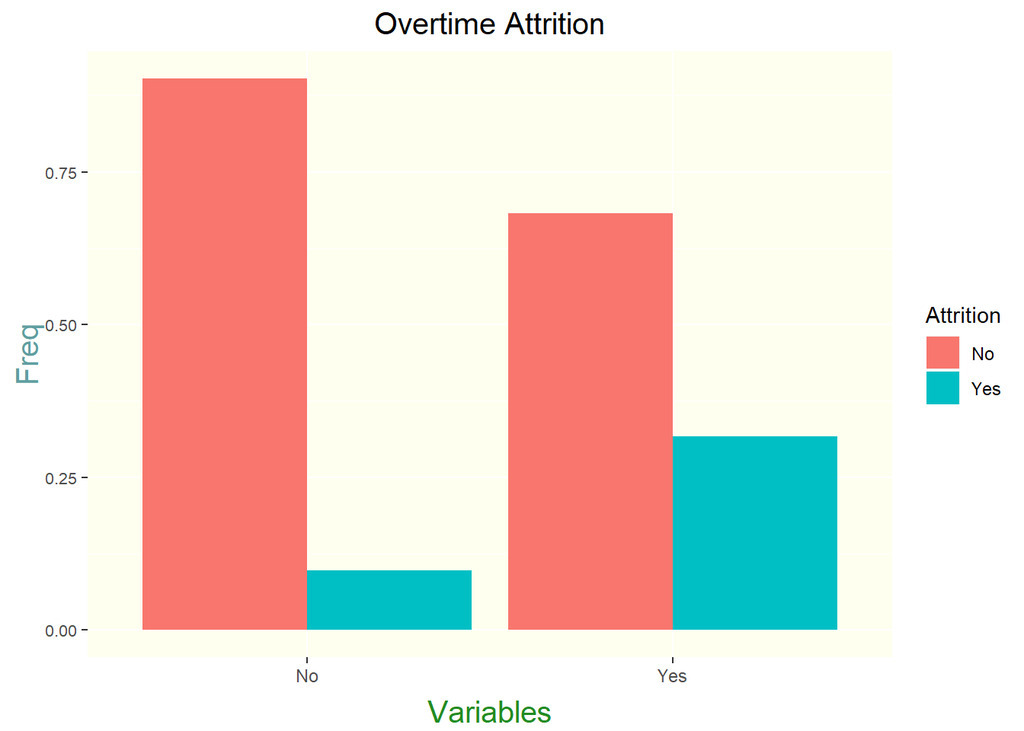

```r
ggplot(data=OverTime_Table, aes(x=Var1, y=Freq, fill=Var2)) +
  geom_bar(stat="identity", position=position_dodge()) +
theme(
        panel.background = element_rect(fill = 'ivory1'),
        plot.title = element_text(hjust = 0.5, size=15),
        axis.text.y = element_text(size=8),
        axis.title.x = element_text(color="forestgreen", vjust=-0.35, size=15),
        axis.title.y = element_text(color="cadetblue" , vjust=0.35, size=15)
        )  +
  labs(fill = "Attrition") +
  ggtitle("Overtime Attrition")+
  xlab("Variables")
```

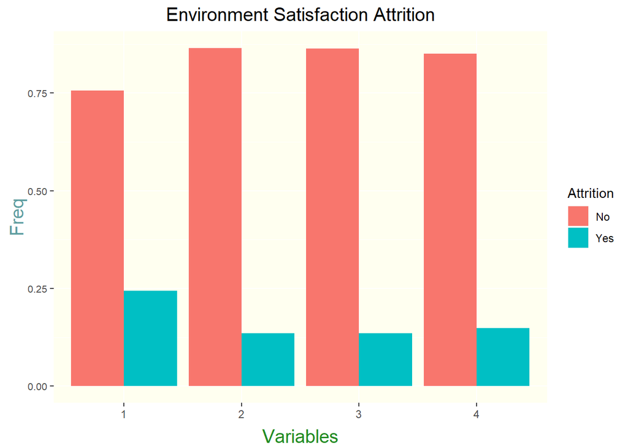

```r
ggplot(data=EnvirSat_Table, aes(x=Var1, y=Freq, fill=Var2)) +
  geom_bar(stat="identity", position=position_dodge()) +
theme(
        panel.background = element_rect(fill = 'ivory1'),
        plot.title = element_text(hjust = 0.5, size=15),
        axis.text.y = element_text(size=8),
        axis.title.x = element_text(color="forestgreen", vjust=-0.35, size=15),
        axis.title.y = element_text(color="cadetblue" , vjust=0.35, size=15)
        )  +
  labs(fill = "Attrition") +
  ggtitle("Environment Satisfaction Attrition")+
  xlab("Variables")
```

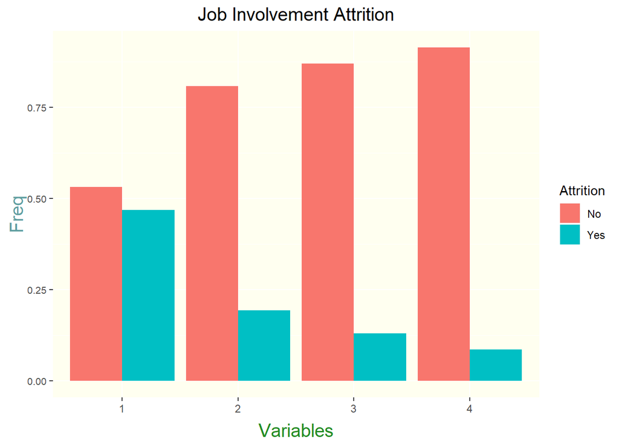

```r
ggplot(data=JobInv_Table, aes(x=Var1, y=Freq, fill=Var2)) +
  geom_bar(stat="identity", position=position_dodge()) +
theme(
        panel.background = element_rect(fill = 'ivory1'),
        plot.title = element_text(hjust = 0.5, size=15),
        axis.text.y = element_text(size=8),
        axis.title.x = element_text(color="forestgreen", vjust=-0.35, size=15),
        axis.title.y = element_text(color="cadetblue" , vjust=0.35, size=15)
        )  +
  labs(fill = "Attrition") +
  ggtitle("Job Involvement Attrition")+
  xlab("Variables")
```

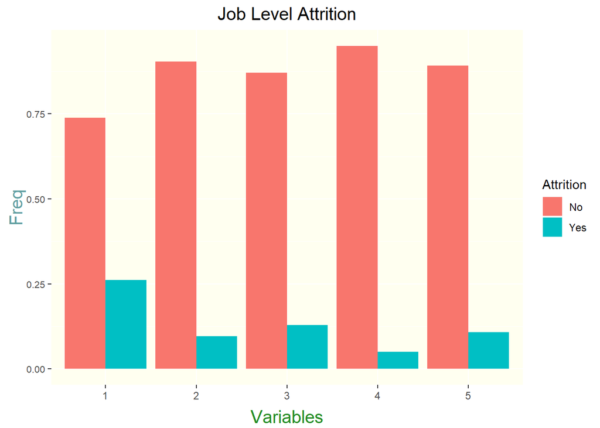

```r
ggplot(data=JobLev_Table, aes(x=Var1, y=Freq, fill=Var2)) +
  geom_bar(stat="identity", position=position_dodge()) +
theme(
        panel.background = element_rect(fill = 'ivory1'),
        plot.title = element_text(hjust = 0.5, size=15),
        axis.text.y = element_text(size=8),
        axis.title.x = element_text(color="forestgreen", vjust=-0.35, size=15),
        axis.title.y = element_text(color="cadetblue" , vjust=0.35, size=15)
        )  +
  labs(fill = "Attrition") +
  ggtitle("Job Level Attrition")+
  xlab("Variables")
```

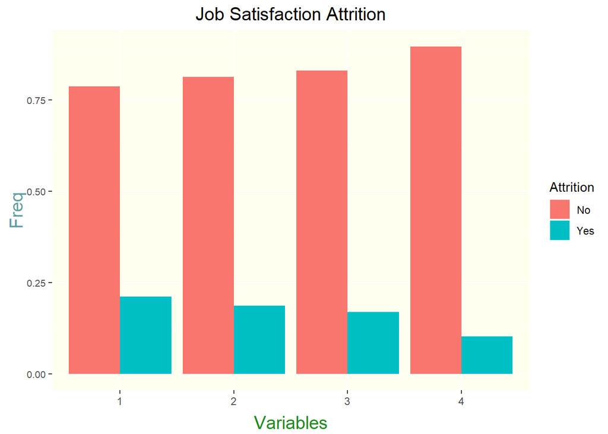

```r
ggplot(data=JobSat_Table, aes(x=Var1, y=Freq, fill=Var2)) +
  geom_bar(stat="identity", position=position_dodge()) +
theme(
        panel.background = element_rect(fill = 'ivory1'),
        plot.title = element_text(hjust = 0.5, size=15),
        axis.text.y = element_text(size=8),
        axis.title.x = element_text(color="forestgreen", vjust=-0.35, size=15),
        axis.title.y = element_text(color="cadetblue" , vjust=0.35, size=15)
        )+
  labs(fill = "Attrition") +
  ggtitle("Job Satisfaction Attrition")+
  xlab("Variables")
```

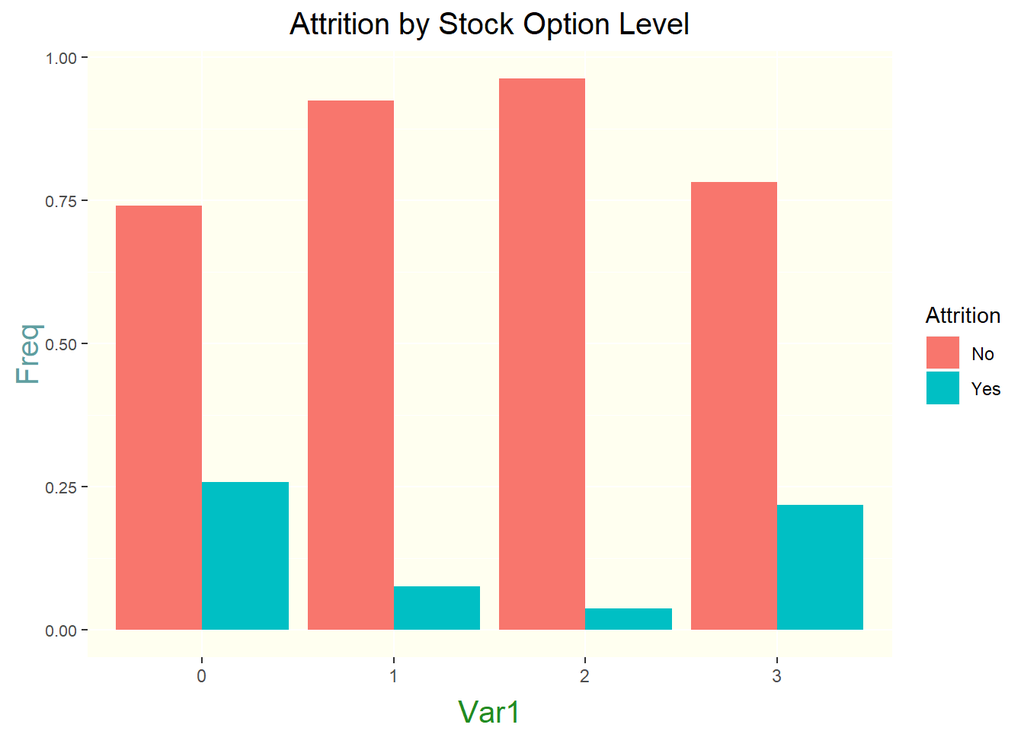

```r
ggplot(data=Stock_Table, aes(x=Var1, y=Freq, fill=Var2)) +
  geom_bar(stat="identity", position=position_dodge()) +
theme(
        panel.background = element_rect(fill = 'ivory1'),
        plot.title = element_text(hjust = 0.5, size=15),
        axis.text.y = element_text(size=8),
        axis.title.x = element_text(color="forestgreen", vjust=-0.35, size=15),
        axis.title.y = element_text(color="cadetblue" , vjust=0.35, size=15)
        )  +
  labs(fill = "Attrition") +
  ggtitle("Attrition by Stock Option Level")
```

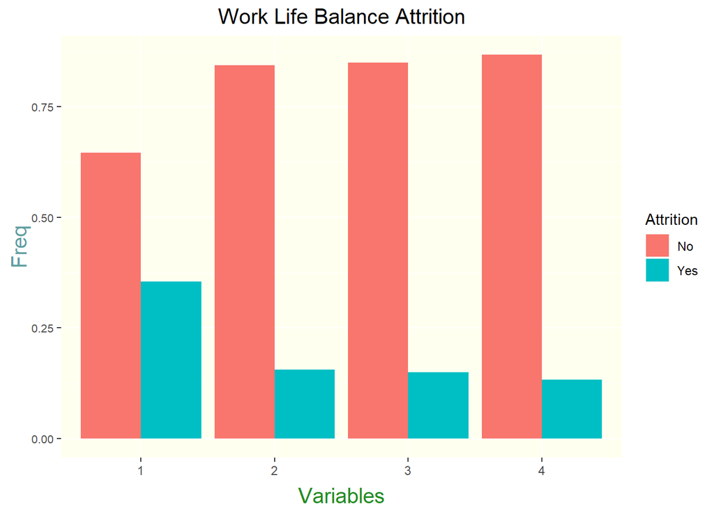

```r
ggplot(data=WorkLife_Table, aes(x=Var1, y=Freq, fill=Var2)) +
  geom_bar(stat="identity", position=position_dodge()) +
  theme(
        panel.background = element_rect(fill = 'ivory1'),
        plot.title = element_text(hjust = 0.5, size=15),
        axis.text.y = element_text(size=8),
        axis.title.x = element_text(color="forestgreen", vjust=-0.35, size=15),
        axis.title.y = element_text(color="cadetblue" , vjust=0.35, size=15)
        )  +
  labs(fill = "Attrition") +
  ggtitle("Work Life Balance Attrition")+
  xlab("Variables")
```

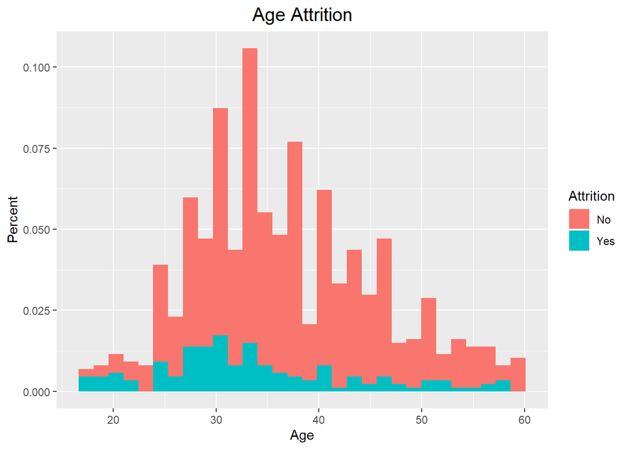

```r
#Plotting Continuous Variable Variance by Attrition
ggplot(data=EmpData2, aes(x=Age, fill=Attrition)) +
  ylab("Percent") +
  geom_histogram(aes(y=(..count..)/sum(..count..)))+
  ggtitle("Age Attrition") +
  theme(plot.title = element_text(hjust = 0.5, size=15))
```

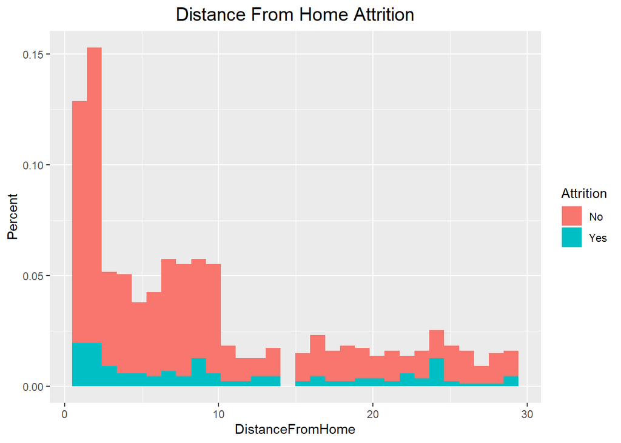

```r
ggplot(data=EmpData2, aes(x=DistanceFromHome, fill=Attrition)) +
  ylab("Percent") +
  geom_histogram(aes(y=(..count..)/sum(..count..))) +
  ggtitle("Distance From Home Attrition")+
  theme(plot.title = element_text(hjust = 0.5, size=15))
```

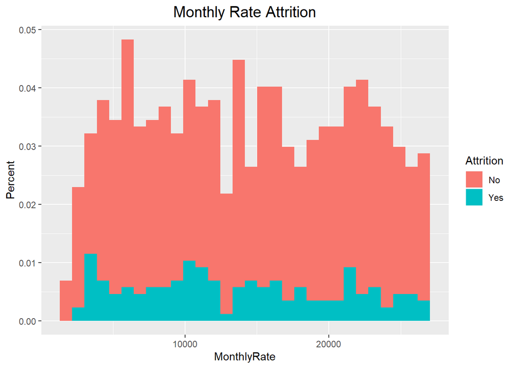

```r
ggplot(data=EmpData2, aes(x=MonthlyRate, fill=Attrition)) +
  ylab("Percent") +
  geom_histogram(aes(y=(..count..)/sum(..count..))) +
  ggtitle("Monthly Rate Attrition")+
  theme(plot.title = element_text(hjust = 0.5, size=15))
```

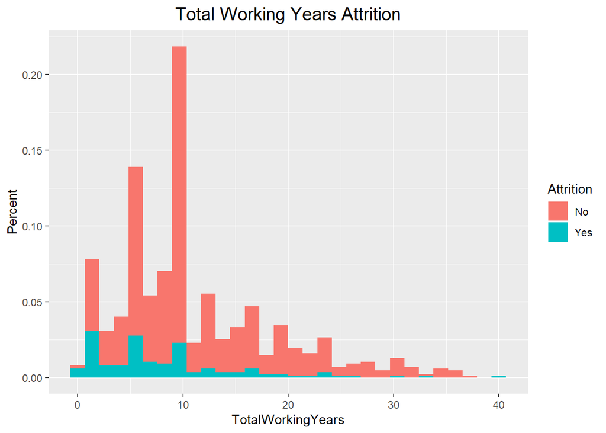

```r
ggplot(data=EmpData2, aes(x=TotalWorkingYears, fill=Attrition)) +
  ylab("Percent") +
  geom_histogram(aes(y=(..count..)/sum(..count..))) +
  ggtitle("Total Working Years Attrition")+
  theme(plot.title = element_text(hjust = 0.5, size=15))
```

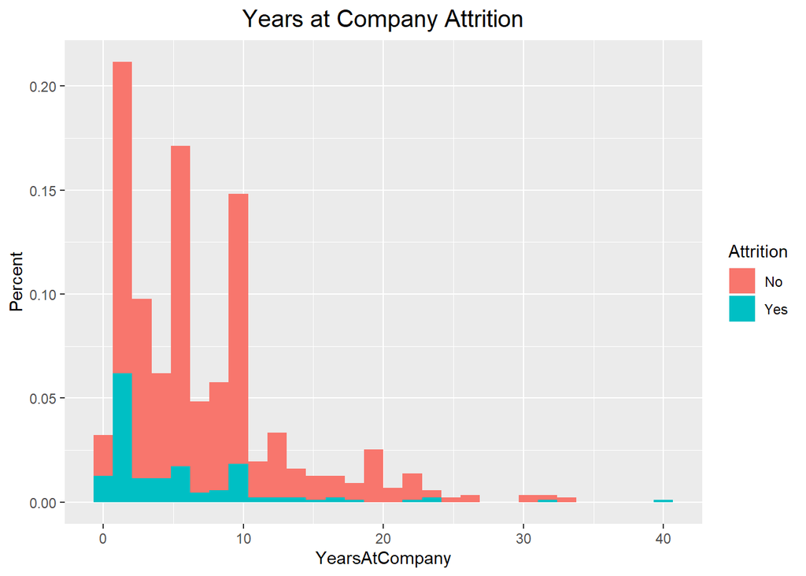

```r
ggplot(data=EmpData2, aes(x=YearsAtCompany, fill=Attrition)) +
  ylab("Percent") +
  geom_histogram(aes(y=(..count..)/sum(..count..))) +
  ggtitle("Years at Company Attrition")+
  theme(plot.title = element_text(hjust = 0.5, size=15))
```

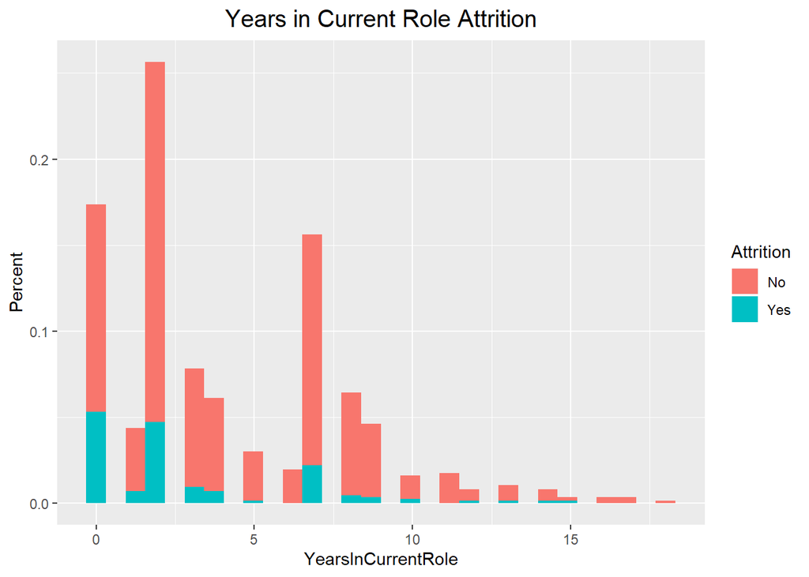

```r
ggplot(data=EmpData2, aes(x=YearsInCurrentRole, fill=Attrition)) +
  ylab("Percent") +
  geom_histogram(aes(y=(..count..)/sum(..count..))) +
  ggtitle("Years in Current Role Attrition")+
  theme(plot.title = element_text(hjust = 0.5, size=15))
```

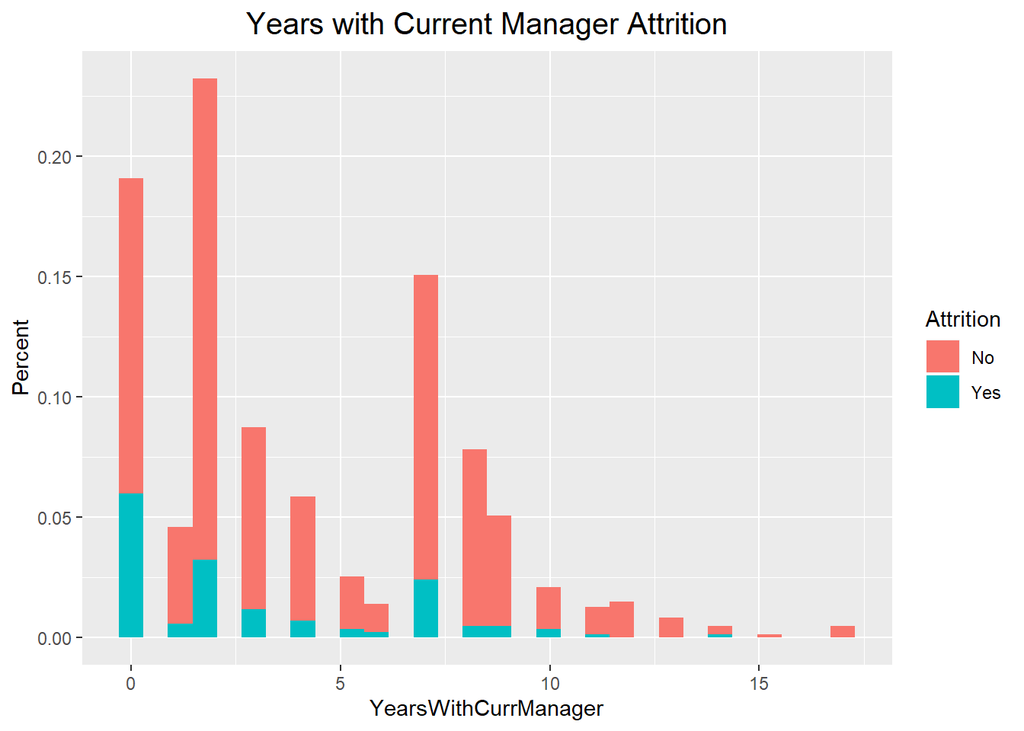

```r
ggplot(data=EmpData2, aes(x=YearsWithCurrManager, fill=Attrition)) +
  ylab("Percent") +
  geom_histogram(aes(y=(..count..)/sum(..count..))) +
  ggtitle("Years with Current Manager Attrition")+
  theme(plot.title = element_text(hjust = 0.5, size=15))
```

####Things of Note:

- The Departments that have the highest Attrition Rate are Sales (21.61%), HR (17.14%), and Research and Development (13.34%).
- The Attrition Rate increases the more an employee has to travel.
- Attrition Rates are highest with employees who have no Stocks (StockLevel = 0) at (25.86%) or who have the most amount of stocks (Stock Level = 3) at (21.82%).
- Looking at Attrition Rate for Divorcees vs the employees who are married or single, the Divorcees have the lowest Attrition Rate at 6.28%, while those who are married have a 14.15% Attrition Rate and the single employees have a 26.02% Attrition Rate.
- Looking at specific Job Roles of these Departments, it seems those with a leadership role (Directors, Managers, and Executives) have lower Attrition Rates than those who work under them (Representatives, Technicians, Research Scientists).
- This is holds true for for Overtime as well since the Leadership roles do not qualify for Overtime have a much lower Attrition Rate (9.71%) compared to those who do qualify for Overtime in Non-Leadership roles (31.75%).
- Work Life Balance has a negative correlation with Attrition Rate, that is the better the Balance (values 1-4) the lower the Attrition Rate.
- Attrition Rate decreases as Job Involvement increases as well as when Job Satisfaction increases (negative correlation).

##Classifing Attrition: Naive Bayes Model

```r
##https://rpubs.com/lytran/408065
#Data Partitioning
set.seed(7)
trainIndex <- createDataPartition(EmpData2$Attrition, p=0.7)$Resample1
train <- EmpData2[trainIndex, ]
test <- EmpData2[-trainIndex, ]
# Total Check
print(table(EmpData2$Attrition))
```

```
##
##  No Yes
## 730 140
```

```r
print(table(train$Attrition))
```

```
##
##  No Yes
## 511  98
```

```r
print(table(test$Attrition))
```

```
##
##  No Yes
## 219  42
```

```r
#Classifier
ClassPrint <- function(model){
  trainPrediction <- predict(model, newdata = train, type = "class")
  trainTable <- table(train$Attrition, trainPrediction)
  testPrediction <- predict(Classifier_Model, newdata=test, type="class")
  testTable <- table(test$Attrition, testPrediction)
  trainAcc <- (trainTable[1,1]+trainTable[2,2])/sum(trainTable)
  testAcc <- (testTable[1,1]+testTable[2,2])/sum(testTable)
  message("Contingency Table for Training Data")
  print(trainTable)
  message("Contingency Table for Test Data")
  print(testTable)
  message("Accuracy")
  print(round(cbind(trainAccuracy=trainAcc, testAccuracy=testAcc),3))
  message("Training Specificity")
  print(trainTable[1,1]/(trainTable[1,1]+trainTable[2,1]))
  message("Test Specificity")
  print(testTable[1,1]/(testTable[1,1]+testTable[2,1]))
  message("Training Sensitivity")
  print(trainTable[2,2]/(trainTable[1,2]+trainTable[2,2]))
  message("Test Sensitivity")
  print(testTable[2,2]/(testTable[1,2]+testTable[2,2]))
}
#Classifier Models
#Model1 (all Variables)
NB_Classfier_1 <- naiveBayes(Attrition~., data=train)
print(NB_Classfier_1)
```

```
##
## Naive Bayes Classifier for Discrete Predictors
##
## Call:
## naiveBayes.default(x = X, y = Y, laplace = laplace)
##
## A-priori probabilities:
## Y
##        No       Yes
## 0.8390805 0.1609195
##
## Conditional probabilities:
##      ID
## Y         [,1]     [,2]
##   No  424.9765 247.7172
##   Yes 478.0000 247.4977
##
##      Age
## Y         [,1]     [,2]
##   No  37.51076  8.89191
##   Yes 34.60204 10.14812
##
##      BusinessTravel
## Y     Non-Travel Travel_Frequently Travel_Rarely
##   No  0.11545988        0.14481409    0.73972603
##   Yes 0.09183673        0.24489796    0.66326531
##
##      DailyRate
## Y         [,1]     [,2]
##   No  817.8767 402.6660
##   Yes 761.2041 403.2676
##
##      Department
## Y     Human Resources Research & Development      Sales
##   No       0.04305284             0.67514677 0.28180039
##   Yes      0.04081633             0.53061224 0.42857143
##
##      DistanceFromHome
## Y          [,1]     [,2]
##   No   9.174168 7.975883
```

[output cut: 132 more lines]

```
##
##      YearsInCurrentRole
## Y         [,1]     [,2]
##   No  4.455969 3.745523
##   Yes 2.785714 3.234001
##
##      YearsSinceLastPromotion
## Y         [,1]     [,2]
##   No  2.127202 3.095453
##   Yes 1.979592 3.277476
##
##      YearsWithCurrManager
## Y         [,1]     [,2]
##   No  4.283757 3.607687
##   Yes 2.653061 2.991748
```

```r
Classifier_Model <- NB_Classfier_1
ClassPrint(Classifier_Model)
```

```
## Contingency Table for Training Data
```

```
##      trainPrediction
##        No Yes
##   No  451  60
##   Yes  34  64
```

```
## Contingency Table for Test Data
```

```
##      testPrediction
##        No Yes
##   No  196  23
##   Yes  18  24
```

```
## Accuracy
```

```
##      trainAccuracy testAccuracy
## [1,]         0.846        0.843
```

```
## Training Specificity
```

```
## [1] 0.9298969
```

```
## Test Specificity
```

```
## [1] 0.9158879
```

```
## Training Sensitivity
```

```
## [1] 0.516129
```

```
## Test Sensitivity
```

```
## [1] 0.5106383
```

```r
#Model2
#Removed low variance columns (DailyRate, Department, Gender, PerformanceRating, RelationshipSatisfaction). Also removed columns that have a high correlation with multiple other columns (Age, MonthlyIncome, TotalWorkingYears).
NB_Classfier_2 <- naiveBayes(Attrition~BusinessTravel+ DistanceFromHome+ Education+ EducationField+ EnvironmentSatisfaction+ HourlyRate+ JobInvolvement+ JobLevel+ JobRole+ JobSatisfaction+ MaritalStatus+ MonthlyRate+ NumCompaniesWorked+ OverTime+ PercentSalaryHike+ StockOptionLevel+ TrainingTimesLastYear+ WorkLifeBalance+ YearsAtCompany+ YearsInCurrentRole+ YearsSinceLastPromotion+ YearsWithCurrManager, data=train)
print(NB_Classfier_2)
```

```
##
## Naive Bayes Classifier for Discrete Predictors
##
## Call:
## naiveBayes.default(x = X, y = Y, laplace = laplace)
##
## A-priori probabilities:
## Y
##        No       Yes
## 0.8390805 0.1609195
##
## Conditional probabilities:
##      BusinessTravel
## Y     Non-Travel Travel_Frequently Travel_Rarely
##   No  0.11545988        0.14481409    0.73972603
##   Yes 0.09183673        0.24489796    0.66326531
##
##      DistanceFromHome
## Y          [,1]     [,2]
##   No   9.174168 7.975883
##   Yes 10.551020 8.480569
##
##      Education
## Y              1          2          3          4          5
##   No  0.10176125 0.20156556 0.37181996 0.29549902 0.02935421
##   Yes 0.11224490 0.23469388 0.42857143 0.19387755 0.03061224
##
##      EducationField
## Y     Human Resources Life Sciences  Marketing    Medical      Other
##   No       0.01761252    0.42661448 0.11154599 0.30724070 0.06066536
##   Yes      0.03061224    0.38775510 0.18367347 0.27551020 0.03061224
##      EducationField
## Y     Technical Degree
##   No        0.07632094
##   Yes       0.09183673
##
##      EnvironmentSatisfaction
## Y             1         2         3         4
##   No  0.1663405 0.2172211 0.3111546 0.3052838
##   Yes 0.2755102 0.1632653 0.2755102 0.2857143
```

[output cut: 82 more lines]

```
##
##      YearsInCurrentRole
## Y         [,1]     [,2]
##   No  4.455969 3.745523
##   Yes 2.785714 3.234001
##
##      YearsSinceLastPromotion
## Y         [,1]     [,2]
##   No  2.127202 3.095453
##   Yes 1.979592 3.277476
##
##      YearsWithCurrManager
## Y         [,1]     [,2]
##   No  4.283757 3.607687
##   Yes 2.653061 2.991748
```

```r
Classifier_Model <- NB_Classfier_2
ClassPrint(Classifier_Model)
```

```
## Contingency Table for Training Data
```

```
##      trainPrediction
##        No Yes
##   No  465  46
##   Yes  39  59
```

```
## Contingency Table for Test Data
```

```
##      testPrediction
##        No Yes
##   No  206  13
##   Yes  19  23
```

```
## Accuracy
```

```
##      trainAccuracy testAccuracy
## [1,]          0.86        0.877
```

```
## Training Specificity
```

```
## [1] 0.922619
```

```
## Test Specificity
```

```
## [1] 0.9155556
```

```
## Training Sensitivity
```

```
## [1] 0.5619048
```

```
## Test Sensitivity
```

```
## [1] 0.6388889
```

```r
#Model3
#Only using Variables that are siginficant with respect to Difference in Attrition Rate (p-value < 0.05)
NB_Classfier_3 <- naiveBayes(Attrition~BusinessTravel + Department + JobRole + MaritalStatus + OverTime + EnvironmentSatisfaction + JobInvolvement + JobLevel + JobSatisfaction + StockOptionLevel + WorkLifeBalance + Age + DistanceFromHome + TotalWorkingYears + YearsAtCompany + YearsInCurrentRole, data=train)
print(NB_Classfier_3)
```

```
##
## Naive Bayes Classifier for Discrete Predictors
##
## Call:
## naiveBayes.default(x = X, y = Y, laplace = laplace)
##
## A-priori probabilities:
## Y
##        No       Yes
## 0.8390805 0.1609195
##
## Conditional probabilities:
##      BusinessTravel
## Y     Non-Travel Travel_Frequently Travel_Rarely
##   No  0.11545988        0.14481409    0.73972603
##   Yes 0.09183673        0.24489796    0.66326531
##
##      Department
## Y     Human Resources Research & Development      Sales
##   No       0.04305284             0.67514677 0.28180039
##   Yes      0.04081633             0.53061224 0.42857143
##
##      JobRole
## Y     Healthcare Representative Human Resources Laboratory Technician
##   No                 0.08806262      0.02935421            0.18590998
##   Yes                0.04081633      0.04081633            0.23469388
##      JobRole
## Y        Manager Manufacturing Director Research Director
##   No  0.06653620             0.10176125        0.08023483
##   Yes 0.04081633             0.02040816        0.01020408
##      JobRole
## Y     Research Scientist Sales Executive Sales Representative
##   No          0.18786693      0.22113503           0.03913894
##   Yes         0.20408163      0.22448980           0.18367347
##
##      MaritalStatus
## Y      Divorced   Married    Single
##   No  0.2289628 0.4990215 0.2720157
##   Yes 0.1020408 0.4387755 0.4591837
##
```

[output cut: 44 more lines]

```
##
##      TotalWorkingYears
## Y          [,1]     [,2]
##   No  11.544031 7.520268
##   Yes  8.357143 7.858609
##
##      YearsAtCompany
## Y         [,1]     [,2]
##   No  7.082192 5.743632
##   Yes 5.081633 6.711543
##
##      YearsInCurrentRole
## Y         [,1]     [,2]
##   No  4.455969 3.745523
##   Yes 2.785714 3.234001
```

```r
Classifier_Model <- NB_Classfier_3
ClassPrint(Classifier_Model)
```

```
## Contingency Table for Training Data
```

```
##      trainPrediction
##        No Yes
##   No  470  41
##   Yes  44  54
```

```
## Contingency Table for Test Data
```

```
##      testPrediction
##        No Yes
##   No  204  15
##   Yes  17  25
```

```
## Accuracy
```

```
##      trainAccuracy testAccuracy
## [1,]          0.86        0.877
```

```
## Training Specificity
```

```
## [1] 0.9143969
```

```
## Test Specificity
```

```
## [1] 0.9230769
```

```
## Training Sensitivity
```

```
## [1] 0.5684211
```

```
## Test Sensitivity
```

```
## [1] 0.625
```

```r
#Model4
#Keeping everything from Model3
#But, removing TotalWorkingYears and YearsAtCompany as they are both highly correlated with each other and can possibly be explained by Age and YearsInCurrentRole
NB_Classfier_4 <- naiveBayes(Attrition~BusinessTravel + Department + JobRole + MaritalStatus + OverTime + EnvironmentSatisfaction + JobInvolvement + JobLevel + JobSatisfaction + StockOptionLevel + WorkLifeBalance + Age + DistanceFromHome  + YearsInCurrentRole, data=train)
print(NB_Classfier_4)
```

```
##
## Naive Bayes Classifier for Discrete Predictors
##
## Call:
## naiveBayes.default(x = X, y = Y, laplace = laplace)
##
## A-priori probabilities:
## Y
##        No       Yes
## 0.8390805 0.1609195
##
## Conditional probabilities:
##      BusinessTravel
## Y     Non-Travel Travel_Frequently Travel_Rarely
##   No  0.11545988        0.14481409    0.73972603
##   Yes 0.09183673        0.24489796    0.66326531
##
##      Department
## Y     Human Resources Research & Development      Sales
##   No       0.04305284             0.67514677 0.28180039
##   Yes      0.04081633             0.53061224 0.42857143
##
##      JobRole
## Y     Healthcare Representative Human Resources Laboratory Technician
##   No                 0.08806262      0.02935421            0.18590998
##   Yes                0.04081633      0.04081633            0.23469388
##      JobRole
## Y        Manager Manufacturing Director Research Director
##   No  0.06653620             0.10176125        0.08023483
##   Yes 0.04081633             0.02040816        0.01020408
##      JobRole
## Y     Research Scientist Sales Executive Sales Representative
##   No          0.18786693      0.22113503           0.03913894
##   Yes         0.20408163      0.22448980           0.18367347
##
##      MaritalStatus
## Y      Divorced   Married    Single
##   No  0.2289628 0.4990215 0.2720157
##   Yes 0.1020408 0.4387755 0.4591837
##
```

[output cut: 34 more lines]

```
##
##      Age
## Y         [,1]     [,2]
##   No  37.51076  8.89191
##   Yes 34.60204 10.14812
##
##      DistanceFromHome
## Y          [,1]     [,2]
##   No   9.174168 7.975883
##   Yes 10.551020 8.480569
##
##      YearsInCurrentRole
## Y         [,1]     [,2]
##   No  4.455969 3.745523
##   Yes 2.785714 3.234001
```

```r
Classifier_Model <- NB_Classfier_4 #Change for each new model
ClassPrint(Classifier_Model)
```

```
## Contingency Table for Training Data
```

```
##      trainPrediction
##        No Yes
##   No  481  30
##   Yes  48  50
```

```
## Contingency Table for Test Data
```

```
##      testPrediction
##        No Yes
##   No  210   9
##   Yes  18  24
```

```
## Accuracy
```

```
##      trainAccuracy testAccuracy
## [1,]         0.872        0.897
```

```
## Training Specificity
```

```
## [1] 0.9092628
```

```
## Test Specificity
```

```
## [1] 0.9210526
```

```
## Training Sensitivity
```

```
## [1] 0.625
```

```
## Test Sensitivity
```

```
## [1] 0.7272727
```

####Model 4 is the best classification model and will be used for identifying attrition. - This model is 87.2% accurate on the training set and 89.7% accurate on the test set. The training and test set sensitivity (correctly estimate true attrition) is: - Training: 62.5% - Test: 72.73% - The training and test set specificity (correctly estimate employees who did not leave) is: - Training: 90.93% - Test: 92.11%

##Predicting Attrition for Dataset with no Attrition

```r
#Predicting Attrition for Dataset with no Attrition
PredictedAT <- predict(Classifier_Model,newdata = Attr_Data,type = 'class')
Attr_Data$Attrition <- PredictedAT
head(Attr_Data)
```

```
##     ID Age    BusinessTravel DailyRate             Department
## 1 1171  35     Travel_Rarely       750 Research & Development
## 2 1172  33     Travel_Rarely       147        Human Resources
## 3 1173  26     Travel_Rarely      1330 Research & Development
## 4 1174  55     Travel_Rarely      1311 Research & Development
## 5 1175  29     Travel_Rarely      1246                  Sales
## 6 1176  51 Travel_Frequently      1456 Research & Development
##   DistanceFromHome Education  EducationField EmployeeNumber
## 1               28         3   Life Sciences           1596
## 2                2         3 Human Resources           1207
## 3               21         3         Medical           1107
## 4                2         3   Life Sciences            505
## 5               19         3   Life Sciences           1497
## 6                1         4         Medical            145
##   EnvironmentSatisfaction Gender HourlyRate JobInvolvement JobLevel
```

[output cut: 48 more lines]

```r
dim(Attr_Data)
```

```
## [1] 300  33
```

```r
#Exporting Results to .csv
#write.csv(Attr_Data[,c(1,33)],"Case2PredictionsIbrahim Attrition.csv")
```

##Linear Regression: Predicting Montly Income

```r
#Fit full linear model
LinearModel <- lm(MonthlyIncome ~ ., train)
summary(LinearModel)
```

```
##
## Call:
## lm(formula = MonthlyIncome ~ ., data = train)
##
## Residuals:
##     Min      1Q  Median      3Q     Max
## -2686.4  -600.6   -81.1   517.4  3668.4
##
## Coefficients:
##                                    Estimate Std. Error t value Pr(>|t|)
## (Intercept)                       2.364e+03  7.885e+02   2.999 0.002836
## ID                               -1.953e-01  1.727e-01  -1.131 0.258691
## Age                               1.014e+00  6.257e+00   0.162 0.871326
## AttritionYes                      1.153e+02  1.367e+02   0.843 0.399325
## BusinessTravelTravel_Frequently   3.464e+02  1.635e+02   2.119 0.034573
## BusinessTravelTravel_Rarely       4.162e+02  1.341e+02   3.104 0.002013
## DailyRate                         2.355e-01  1.036e-01   2.274 0.023359
## DepartmentResearch & Development  1.894e+02  4.980e+02   0.380 0.703830
## DepartmentSales                  -4.025e+02  5.256e+02  -0.766 0.444044
## DistanceFromHome                 -4.132e+00  5.276e+00  -0.783 0.433852
## Education2                        3.944e+01  1.590e+02   0.248 0.804239
## Education3                        8.885e+01  1.466e+02   0.606 0.544748
## Education4                        1.383e+02  1.596e+02   0.866 0.386821
## Education5                       -1.088e+02  2.841e+02  -0.383 0.701892
## EducationFieldLife Sciences       1.421e+02  4.052e+02   0.351 0.725902
## EducationFieldMarketing           1.515e+02  4.304e+02   0.352 0.725003
## EducationFieldMedical             1.357e+02  4.056e+02   0.335 0.738076
## EducationFieldOther               3.164e+02  4.350e+02   0.727 0.467237
## EducationFieldTechnical Degree    2.903e+01  4.248e+02   0.068 0.945535
## EmployeeNumber                    1.222e-01  7.004e-02   1.745 0.081496
## EnvironmentSatisfaction2         -5.324e+01  1.337e+02  -0.398 0.690569
## EnvironmentSatisfaction3          5.316e+00  1.246e+02   0.043 0.965991
## EnvironmentSatisfaction4         -3.088e+01  1.237e+02  -0.250 0.803024
## GenderMale                        5.367e+01  8.535e+01   0.629 0.529733
## HourlyRate                       -8.479e-01  2.098e+00  -0.404 0.686197
## JobInvolvement2                  -8.390e+01  2.022e+02  -0.415 0.678387
## JobInvolvement3                  -1.653e+02  1.964e+02  -0.842 0.400413
## JobInvolvement4                   8.199e+01  2.331e+02   0.352 0.725197
## JobLevel2                         1.707e+03  1.739e+02   9.817  < 2e-16
## JobLevel3                         4.784e+03  2.354e+02  20.320  < 2e-16
```

[output cut: 102 more lines]

```
## TrainingTimesLastYear5
## TrainingTimesLastYear6
## WorkLifeBalance2
## WorkLifeBalance3
## WorkLifeBalance4
## YearsAtCompany
## YearsInCurrentRole
## YearsSinceLastPromotion          *
## YearsWithCurrManager
## ---
## Signif. codes:  0 '***' 0.001 '**' 0.01 '*' 0.05 '.' 0.1 ' ' 1
##
## Residual standard error: 982.5 on 539 degrees of freedom
## Multiple R-squared:  0.9615, Adjusted R-squared:  0.9566
## F-statistic: 195.2 on 69 and 539 DF,  p-value: < 2.2e-16
```

```r
#Model Selction: Forward, Backward, Stepwise
TrainControl <- trainControl(method = "cv", number = 10)
# Backward Selection
BackwardModel <- train(MonthlyIncome ~., data = train, method = "leapBackward", tuneGrid = data.frame(nvmax = 1:20), trControl = TrainControl)
BackwardModel$results #includes RMSE
```

```
##    nvmax      RMSE  Rsquared       MAE   RMSESD  RsquaredSD     MAESD
## 1      1 3743.1824 0.3607727 2883.3054 309.2467 0.127185310 197.51929
## 2      2 2771.3471 0.6528982 2167.8484 139.6230 0.059207615 125.61799
## 3      3 1733.7097 0.8650558 1420.4010 150.6986 0.021604660 109.89681
## 4      4 1269.5085 0.9291411  925.2511 133.3211 0.013649997  86.49816
## 5      5 1166.1825 0.9402692  881.5967 146.3070 0.013656776  91.87180
## 6      6 1040.4810 0.9521820  781.9355 137.2186 0.010704876  65.44530
## 7      7 1020.8332 0.9539850  759.1419 152.3635 0.011698380  71.74701
## 8      8 1007.1149 0.9552864  758.6113 147.2859 0.011331006  71.23277
## 9      9 1006.5847 0.9555650  763.4126 137.0129 0.010439311  64.93611
## 10    10  992.6067 0.9567745  758.3354 129.3782 0.009370846  56.39619
## 11    11  977.4734 0.9579841  752.0872 135.5665 0.010047836  65.97242
## 12    12  986.1221 0.9571773  754.0486 133.8877 0.010310824  61.85746
## 13    13  985.9025 0.9572434  754.0685 131.0491 0.010045769  59.56347
## 14    14  991.6208 0.9567149  755.1580 123.6543 0.009694622  54.00582
## 15    15  992.4226 0.9566299  757.2281 124.0922 0.009880080  57.32722
## 16    16  990.6735 0.9567886  756.8589 125.0307 0.010274500  57.45494
## 17    17  996.5403 0.9562533  760.8263 124.8412 0.010465208  58.36191
## 18    18  998.8829 0.9560917  762.0902 124.8004 0.010382317  56.84359
## 19    19 1001.2929 0.9558557  761.9637 124.7790 0.010353162  54.38423
## 20    20 1005.6905 0.9554421  765.3670 129.0988 0.010614744  54.09544
```

```r
BackwardPredict <- predict(BackwardModel, newdata = test)
test$BackwardPredict <- BackwardPredict
# Forward Selection
ForwardModel <- train(MonthlyIncome ~., data = train, method = "leapForward", tuneGrid = data.frame(nvmax = 1:20), trControl = TrainControl)
ForwardModel$results #includes RMSE
```

```
##    nvmax      RMSE  Rsquared       MAE   RMSESD RsquaredSD     MAESD
## 1      1 2933.7712 0.6164743 2210.8005 213.4496 0.06565329 148.88314
## 2      2 2694.9318 0.6785702 2016.4694 221.8556 0.06680451 143.03771
## 3      3 2417.4272 0.7433343 1822.1483 275.7294 0.06566887 198.25192
## 4      4 1840.3193 0.8508315 1455.8072 169.8466 0.02426862 119.25849
## 5      5 1567.9021 0.8923138 1188.3004 228.8116 0.02449821 232.96712
## 6      6 1374.9655 0.9163530 1050.7486 248.3374 0.02654818 226.85950
## 7      7 1170.2683 0.9370623  879.4899 285.0493 0.02847873 226.75355
## 8      8 1074.4170 0.9478327  815.5195 157.8368 0.01563533 124.43684
## 9      9 1014.5351 0.9532468  767.1544 115.3896 0.01316050  67.30336
## 10    10  999.6366 0.9546305  759.1048 115.0038 0.01248431  70.90558
## 11    11  997.8208 0.9547319  761.8142 121.5123 0.01264345  71.46067
## 12    12  993.3510 0.9552484  756.0800 125.0429 0.01225968  79.21723
## 13    13  999.8509 0.9547507  764.6425 125.8903 0.01252941  83.42006
## 14    14 1001.1529 0.9546980  763.7966 120.5192 0.01233309  78.03168
## 15    15 1003.4761 0.9546089  766.3660 117.1275 0.01192729  74.86566
## 16    16 1006.1754 0.9544793  767.4535 115.2323 0.01167257  75.83807
## 17    17 1011.6422 0.9540039  770.4465 118.7311 0.01198964  75.06524
## 18    18 1014.8380 0.9537253  773.2711 113.4149 0.01174837  75.89010
## 19    19 1015.6336 0.9536535  777.5343 110.8201 0.01167923  74.08897
## 20    20 1015.2291 0.9536920  779.2469 106.2198 0.01134660  73.63862
```

```r
ForwardPredict <- predict(ForwardModel, newdata = test)
test$ForwardPredict <- ForwardPredict
# Stepwise Selection
StepwiseModel <- train(MonthlyIncome ~., data = train, method = "leapSeq", tuneGrid = data.frame(nvmax = 1:20), trControl = TrainControl)
StepwiseModel$results #includes RMSE
```

```
##    nvmax      RMSE  Rsquared       MAE    RMSESD RsquaredSD      MAESD
## 1      1 2934.9950 0.6161740 2213.4531  274.8708 0.08582415  180.28028
## 2      2 2699.4557 0.6715159 2025.3109  237.8239 0.07548587  138.70424
## 3      3 1780.9447 0.8566367 1437.6552  225.1752 0.03315731  145.93943
## 4      4 1426.6591 0.9073478 1065.6131  392.5494 0.04134290  308.68224
## 5      5 1225.7258 0.9327956  929.8685  264.7891 0.02694028  201.42529
## 6      6 2077.0172 0.7292003 1582.5104 1742.0470 0.35807368 1332.63208
## 7      7 3803.4937 0.3042178 2887.5123 1056.0431 0.23969188  840.00615
## 8      8 1008.0010 0.9538307  759.5417  148.9633 0.01384193   65.06807
## 9      9 1012.7563 0.9534238  762.8106  142.7984 0.01373122   67.97680
## 10    10 1006.4386 0.9540535  767.7873  127.0194 0.01216350   54.18116
## 11    11  977.3382 0.9568591  749.7284  128.2537 0.01124471   66.35725
## 12    12  991.1966 0.9555525  757.9090  131.4256 0.01205590   73.46050
## 13    13  997.6257 0.9550328  764.6423  128.2004 0.01200933   73.59977
## 14    14 1334.1110 0.8838190 1006.9917 1065.4855 0.22236227  752.82213
## 15    15 1394.9123 0.8741941 1072.7664 1221.9312 0.24913550  963.48691
## 16    16 1278.3696 0.8817643  974.0930  833.8408 0.23095048  618.06099
## 17    17 1743.4489 0.7906264 1329.2418 1566.2457 0.34214201 1212.88770
## 18    18 1004.2740 0.9546972  766.9820  131.8531 0.01235550   79.26358
## 19    19 1601.7078 0.8205075 1221.8230 1251.1810 0.28233655  946.16496
## 20    20 1344.0647 0.8811094 1047.4148 1143.7384 0.23628047  889.61230
```

```r
StepwisePredict <- predict(StepwiseModel, newdata = test)
test$StepwisePredict <- StepwisePredict
#Calculating ASE stats for each model
ASEholderForward = c()
ASEholderBackward = c()
ASEholderStepwise = c()
ASEholderForward = sum((test$ForwardPredict - test$MonthlyIncome)^2)/length(test$MonthlyIncome)
ASEholderBackward = sum((test$BackwardPredict - test$MonthlyIncome)^2)/length(test$MonthlyIncome)
ASEholderStepwise = sum((test$StepwisePredict - test$MonthlyIncome)^2)/length(test$MonthlyIncome)
#ASE Stats
ASEholderForward
```

```
## [1] 1129814
```

```r
ASEholderBackward
```

```
## [1] 1143751
```

```r
ASEholderStepwise
```

```
## [1] 1143751
```

```r
#RMSE Stats
BackwardModel$results
```

```
##    nvmax      RMSE  Rsquared       MAE   RMSESD  RsquaredSD     MAESD
## 1      1 3743.1824 0.3607727 2883.3054 309.2467 0.127185310 197.51929
## 2      2 2771.3471 0.6528982 2167.8484 139.6230 0.059207615 125.61799
## 3      3 1733.7097 0.8650558 1420.4010 150.6986 0.021604660 109.89681
## 4      4 1269.5085 0.9291411  925.2511 133.3211 0.013649997  86.49816
## 5      5 1166.1825 0.9402692  881.5967 146.3070 0.013656776  91.87180
## 6      6 1040.4810 0.9521820  781.9355 137.2186 0.010704876  65.44530
## 7      7 1020.8332 0.9539850  759.1419 152.3635 0.011698380  71.74701
## 8      8 1007.1149 0.9552864  758.6113 147.2859 0.011331006  71.23277
## 9      9 1006.5847 0.9555650  763.4126 137.0129 0.010439311  64.93611
## 10    10  992.6067 0.9567745  758.3354 129.3782 0.009370846  56.39619
## 11    11  977.4734 0.9579841  752.0872 135.5665 0.010047836  65.97242
## 12    12  986.1221 0.9571773  754.0486 133.8877 0.010310824  61.85746
## 13    13  985.9025 0.9572434  754.0685 131.0491 0.010045769  59.56347
## 14    14  991.6208 0.9567149  755.1580 123.6543 0.009694622  54.00582
## 15    15  992.4226 0.9566299  757.2281 124.0922 0.009880080  57.32722
## 16    16  990.6735 0.9567886  756.8589 125.0307 0.010274500  57.45494
## 17    17  996.5403 0.9562533  760.8263 124.8412 0.010465208  58.36191
## 18    18  998.8829 0.9560917  762.0902 124.8004 0.010382317  56.84359
## 19    19 1001.2929 0.9558557  761.9637 124.7790 0.010353162  54.38423
## 20    20 1005.6905 0.9554421  765.3670 129.0988 0.010614744  54.09544
```

```r
ForwardModel$results
```

```
##    nvmax      RMSE  Rsquared       MAE   RMSESD RsquaredSD     MAESD
## 1      1 2933.7712 0.6164743 2210.8005 213.4496 0.06565329 148.88314
## 2      2 2694.9318 0.6785702 2016.4694 221.8556 0.06680451 143.03771
## 3      3 2417.4272 0.7433343 1822.1483 275.7294 0.06566887 198.25192
## 4      4 1840.3193 0.8508315 1455.8072 169.8466 0.02426862 119.25849
## 5      5 1567.9021 0.8923138 1188.3004 228.8116 0.02449821 232.96712
## 6      6 1374.9655 0.9163530 1050.7486 248.3374 0.02654818 226.85950
## 7      7 1170.2683 0.9370623  879.4899 285.0493 0.02847873 226.75355
## 8      8 1074.4170 0.9478327  815.5195 157.8368 0.01563533 124.43684
## 9      9 1014.5351 0.9532468  767.1544 115.3896 0.01316050  67.30336
## 10    10  999.6366 0.9546305  759.1048 115.0038 0.01248431  70.90558
## 11    11  997.8208 0.9547319  761.8142 121.5123 0.01264345  71.46067
## 12    12  993.3510 0.9552484  756.0800 125.0429 0.01225968  79.21723
## 13    13  999.8509 0.9547507  764.6425 125.8903 0.01252941  83.42006
## 14    14 1001.1529 0.9546980  763.7966 120.5192 0.01233309  78.03168
## 15    15 1003.4761 0.9546089  766.3660 117.1275 0.01192729  74.86566
## 16    16 1006.1754 0.9544793  767.4535 115.2323 0.01167257  75.83807
## 17    17 1011.6422 0.9540039  770.4465 118.7311 0.01198964  75.06524
## 18    18 1014.8380 0.9537253  773.2711 113.4149 0.01174837  75.89010
## 19    19 1015.6336 0.9536535  777.5343 110.8201 0.01167923  74.08897
## 20    20 1015.2291 0.9536920  779.2469 106.2198 0.01134660  73.63862
```

```r
StepwiseModel$results
```

```
##    nvmax      RMSE  Rsquared       MAE    RMSESD RsquaredSD      MAESD
## 1      1 2934.9950 0.6161740 2213.4531  274.8708 0.08582415  180.28028
## 2      2 2699.4557 0.6715159 2025.3109  237.8239 0.07548587  138.70424
## 3      3 1780.9447 0.8566367 1437.6552  225.1752 0.03315731  145.93943
## 4      4 1426.6591 0.9073478 1065.6131  392.5494 0.04134290  308.68224
## 5      5 1225.7258 0.9327956  929.8685  264.7891 0.02694028  201.42529
## 6      6 2077.0172 0.7292003 1582.5104 1742.0470 0.35807368 1332.63208
## 7      7 3803.4937 0.3042178 2887.5123 1056.0431 0.23969188  840.00615
## 8      8 1008.0010 0.9538307  759.5417  148.9633 0.01384193   65.06807
## 9      9 1012.7563 0.9534238  762.8106  142.7984 0.01373122   67.97680
## 10    10 1006.4386 0.9540535  767.7873  127.0194 0.01216350   54.18116
## 11    11  977.3382 0.9568591  749.7284  128.2537 0.01124471   66.35725
## 12    12  991.1966 0.9555525  757.9090  131.4256 0.01205590   73.46050
## 13    13  997.6257 0.9550328  764.6423  128.2004 0.01200933   73.59977
## 14    14 1334.1110 0.8838190 1006.9917 1065.4855 0.22236227  752.82213
## 15    15 1394.9123 0.8741941 1072.7664 1221.9312 0.24913550  963.48691
## 16    16 1278.3696 0.8817643  974.0930  833.8408 0.23095048  618.06099
## 17    17 1743.4489 0.7906264 1329.2418 1566.2457 0.34214201 1212.88770
## 18    18 1004.2740 0.9546972  766.9820  131.8531 0.01235550   79.26358
## 19    19 1601.7078 0.8205075 1221.8230 1251.1810 0.28233655  946.16496
## 20    20 1344.0647 0.8811094 1047.4148 1143.7384 0.23628047  889.61230
```

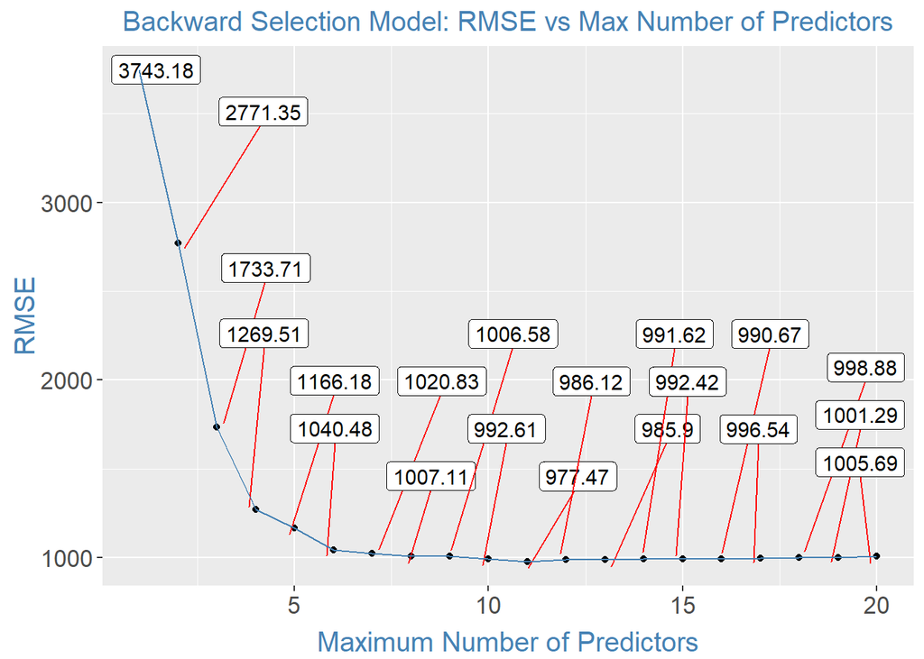

```r
#RMSE Results saved to table
BackModelPlot <- BackwardModel$results
ForModelPlot <- ForwardModel$results
StepModelPlot <- StepwiseModel$results

#Backward Model RMSE Plot
 ggplot(BackModelPlot, aes(x=nvmax, y=RMSE)) +
     geom_point() +
   geom_label_repel(aes(label = round(RMSE,digits=2)),
                  box.padding   = 0.35,
                  point.padding = 0.5,
                  vjust = -5,
                  hjust = -0.05,
                  segment.color = 'red',
                  size = 4) +
  theme(plot.title = element_text(hjust = 0.5, size=15,color="Steelblue"),
        axis.text.y = element_text(size=13),
        axis.text.x = element_text(size=13),
        axis.title.x = element_text(color="Steelblue", vjust=-0.35, size=15),
        axis.title.y = element_text(color="Steelblue" , vjust=0.35, size=15))+
   geom_line( color="steelblue")+
  ggtitle("Backward Selection Model: RMSE vs Max Number of Predictors") +
  xlab("Maximum Number of Predictors")
```

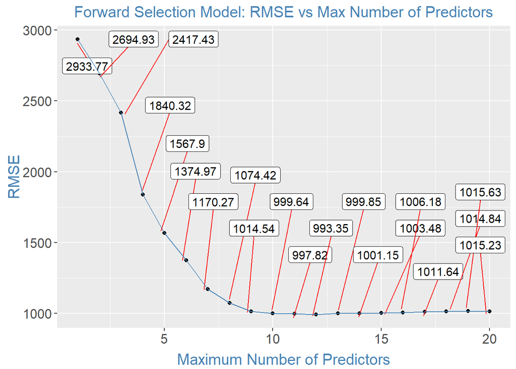

```r
 #Forward Model RMSE Plot
ggplot(ForModelPlot, aes(x=nvmax, y=RMSE)) +
     geom_point() +
   geom_label_repel(aes(label = round(RMSE,digits=2)),
                  box.padding   = 0.35,
                  point.padding = 0.5,
                  vjust = -5,
                  hjust = -0.05,
                  segment.color = 'red',
                  size = 4) +
  theme(plot.title = element_text(hjust = 0.5, size=15,color="Steelblue"),
        axis.text.y = element_text(size=13),
        axis.text.x = element_text(size=13),
        axis.title.x = element_text(color="Steelblue", vjust=-0.35, size=15),
        axis.title.y = element_text(color="Steelblue" , vjust=0.35, size=15))+
   geom_line( color="steelblue")+
  ggtitle("Forward Selection Model: RMSE vs Max Number of Predictors") +
  xlab("Maximum Number of Predictors")
```

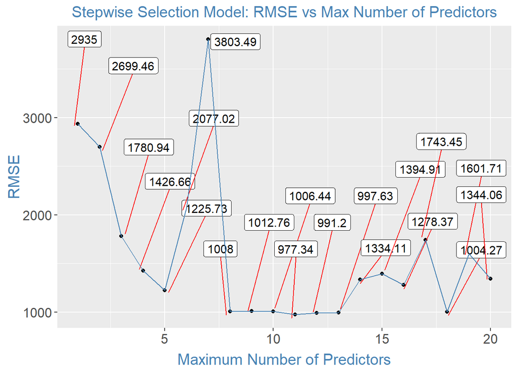

```r
#Stepwise Model RMSE Plot
ggplot(StepModelPlot, aes(x=nvmax, y=RMSE)) +
     geom_point() +
   geom_label_repel(aes(label = round(RMSE,digits=2)),
                  box.padding   = 0.35,
                  point.padding = 0.5,
                  vjust = -5,
                  hjust = -0.05,
                  segment.color = 'red',
                  size = 4) +
  theme(plot.title = element_text(hjust = 0.5, size=15,color="Steelblue"),
        axis.text.y = element_text(size=13),
        axis.text.x = element_text(size=13),
        axis.title.x = element_text(color="Steelblue", vjust=-0.35, size=15),
        axis.title.y = element_text(color="Steelblue" , vjust=0.35, size=15))+
   geom_line( color="steelblue")+
  ggtitle("Stepwise Selection Model: RMSE vs Max Number of Predictors") +
  xlab("Maximum Number of Predictors")
```

##Predicting Montly Income for Validation Dataset

```r
#Predicting Income for Validation Data
Income_Predictions <- predict(BackwardModel, newdata = Income_Data)
Income_Data$MonthlyIncome <- Income_Predictions
head(Income_Data)
```

```
##    ID Age Attrition    BusinessTravel DailyRate             Department
## 1 871  43        No Travel_Frequently      1422                  Sales
## 2 872  33        No     Travel_Rarely       461 Research & Development
## 3 873  55       Yes     Travel_Rarely       267                  Sales
## 4 874  36        No        Non-Travel      1351 Research & Development
## 5 875  27        No     Travel_Rarely      1302 Research & Development
## 6 876  39       Yes     Travel_Rarely       895                  Sales
##   DistanceFromHome Education   EducationField EmployeeNumber
## 1                2         4    Life Sciences           1849
## 2               13         1    Life Sciences            995
## 3               13         4        Marketing           1372
## 4                9         4    Life Sciences           1949
## 5               19         3            Other           1619
## 6                5         3 Technical Degree             42
##   EnvironmentSatisfaction Gender HourlyRate JobInvolvement JobLevel
```

[output cut: 41 more lines]

```r
dim(Income_Data)
```

```
## [1] 300  33
```

```r
#Exporting Results to .csv
#write.csv(Income_Data[,c(1,33)],"Case2PredictionsIbrahim Salary.csv")
```